# Data Science Probability

The textbook for the Data Science course series is [freely available online](https://rafalab.github.io/dsbook/).

This course corresponds to the Probability section of textbook, starting [here](https://rafalab.github.io/dsbook/probability.html).

This course assumes you are comfortable with basic math, algebra, and logical operations. HarvardX has partnered with DataCamp for all assignments in R that allow you to program directly in a browser-based interface. You will not need to download any special software.

Using a combination of a guided introduction through short video lectures and more independent in-depth exploration, you will get to practice your new R skills on real-life applications.

Probability theory is the mathematical foundation of statistical inference which is indispensable for analyzing data affected by chance, and thus essential for data scientists. In this course, you will learn important concepts in probability theory. The motivation for this course is the circumstances surrounding the financial crisis of 2007-2008. Part of what caused this financial crisis was that the risk of certain securities sold by financial institutions was underestimated. To begin to understand this very complicated event, we need to understand the basics of probability. We will introduce important concepts such as random variables, independence, Monte Carlo simulations, expected values, standard errors, and the Central Limit Theorem. These statistical concepts are fundamental to conducting statistical tests on data and understanding whether the data you are analyzing are likely occurring due to an experimental method or to chance. Statistical inference, covered in the next course in this series, builds upon probability theory.

# Learning Objectives

- Important concepts in probability theory including random variables and independence
- How to perform a Monte Carlo simulation
- The meaning of expected values and standard errors and how to compute them in R
- The importance of the Central Limit Theorem

## Course Overview

### Section 1: Discrete Probability

You will learn about basic principles of probability related to categorical data using card games as examples.

### Section 2: Continuous Probability

You will learn about basic principles of probability related to numeric and continuous data.

### Section 3: Random Variables, Sampling Models, and The Central Limit Theorem

You will learn about random variables (numeric outcomes resulting from random processes), how to model data generation procedures as draws from an urn, and the Central Limit Theorem, which applies to large sample sizes.

### Section 4: The Big Short

You will learn how interest rates are determined and how some bad assumptions led to the financial crisis of 2007-2008.

# Section 1 Overview

Section 1 introduces you to Discrete Probability. Section 1 is divided into three parts:

- Introduction to Discrete Probability
- Combinations and Permutations
- Addition Rule and Monty Hall

After completing Section 1, you will be able to:

- Apply basic probability theory to categorical data.
- Perform a Monte Carlo simulation to approximate the results of repeating an experiment over and over, including simulating the outcomes in the Monty Hall problem.
- Distinguish between: sampling with and without replacement, events that are and are not independent, and combinations and permutations.
- Apply the multiplication and addition rules, as appropriate, to calculate the probably of multiple events occurring.
- Use **sapply** instead of a for loop to perform element-wise operations on a function.

## Discrete Probability

The textbook for this section is available [here](https://rafalab.github.io/dsbook/probability.html#discrete-probability).

**Key points**

- The *probability of an event* is the proportion of times the event occurs when we repeat the experiment independently under the same conditions.

$\mbox{Pr}(A)$ = probability of event A

- An *event* is defined as an outcome that can occur when when something happens by chance.
- We can determine probabilities related to discrete variables (picking a red bead, choosing 48 Democrats and 52 Republicans from 100 likely voters) and continuous variables (height over 6 feet).

## Monte Carlo Simulations

The textbook for this section is available [here](https://rafalab.github.io/dsbook/probability.html#monte-carlo-simulations).

**Key points**

- Monte Carlo simulations model the probability of different outcomes by repeating a random process a large enough number of times that the results are similar to what would be observed if the process were repeated forever.
- The **sample** function draws random outcomes from a set of options.
- The **replicate** function repeats lines of code a set number of times. It is used with **sample** and similar functions to run Monte Carlo simulations.

*Code: The rep function and the sample function*

```r
beads <- rep(c("red", "blue"), times = c(2,3))    # create an urn with 2 red, 3 blue
beads    # view beads object
```

```
## [1] "red"  "red"  "blue" "blue" "blue"
```

```r
sample(beads, 1)    # sample 1 bead at random
```

```
## [1] "blue"
```

*Code: Monte Carlo simulation*

Note that your exact outcome values will differ because the sampling is random.

```r
B <- 10000    # number of times to draw 1 bead
events <- replicate(B, sample(beads, 1))    # draw 1 bead, B times
tab <- table(events)    # make a table of outcome counts
tab    # view count table
```

```
## events
## blue  red
## 5990 4010
```

```r
prop.table(tab)    # view table of outcome proportions
```

```
## events
##  blue   red
## 0.599 0.401
```

## Setting the Random Seed

The **set.seed** function

Before we continue, we will briefly explain the following important line of code:

```r
set.seed(1986)
```

Throughout this book, we use random number generators. This implies that many of the results presented can actually change by chance, which then suggests that a frozen version of the book may show a different result than what you obtain when you try to code as shown in the book. This is actually fine since the results are random and change from time to time. However, if you want to to ensure that results are exactly the same every time you run them, you can set R’s random number generation seed to a specific number. Above we set it to 1986. We want to avoid using the same seed every time. A popular way to pick the seed is the year - month - day. For example, we picked 1986 on December 20, 2018: 2018 − 12 − 20 = 1986.

You can learn more about setting the seed by looking at the documentation:

```r
?set.seed
```

In the exercises, we may ask you to set the seed to assure that the results you obtain are exactly what we expect them to be.

**Important note on seeds in R 3.5 and R 3.6**

R was updated to version 3.6 in early 2019. In this update, the default method for setting the seed changed. This means that exercises, videos, textbook excerpts and other code you encounter online may yield a different result based on your version of R.

If you are running R 3.6, you can revert to the original seed setting behavior by adding the argument sample.kind=“Rounding”. For example:

```r
set.seed(1)
set.seed(1, sample.kind="Rounding")    # will make R 3.6 generate a seed as in R 3.5
```

Using the `sample.kind="Rounding"` argument will generate a message:

`non-uniform 'Rounding' sampler used`

This is not a warning or a cause for alarm - it is a confirmation that R is using the alternate seed generation method, and you should expect to receive this message in your console.

**If you use R 3.6, you should always use the second form of set.seed in this course series (outside of DataCamp assignments).** Failure to do so may result in an otherwise correct answer being rejected by the grader. In most cases where a seed is required, you will be reminded of this fact.

## Using the mean Function for Probability

**An important application of the `mean` function**

In R, applying the `mean` function to a logical vector returns the proportion of elements that are TRUE. It is very common to use the `mean` function in this way to calculate probabilities and we will do so throughout the course.

Suppose you have the vector beads:

```r
beads <- rep(c("red", "blue"), times = c(2,3))
beads
```

```
## [1] "red"  "red"  "blue" "blue" "blue"
```

```r
# To find the probability of drawing a blue bead at random, you can run:
mean(beads == "blue")
```

```
## [1] 0.6
```

This code is broken down into steps inside R. First, R evaluates the logical statement `beads == "blue"`, which generates the vector:

`FALSE FALSE TRUE TRUE TRUE`

When the `mean` function is applied, R coerces the logical values to numeric values, changing TRUE to 1 and FALSE to 0:

`0 0 1 1 1`

The mean of the zeros and ones thus gives the proportion of TRUE values. As we have learned and will continue to see, probabilities are directly related to the proportion of events that satisfy a requirement.

## Probability Distributions

The textbook for this section is available [here](https://rafalab.github.io/dsbook/probability.html#discrete-probability-distributions).

**Key points**

- The probability distribution for a variable describes the probability of observing each possible outcome.
- For discrete categorical variables, the probability distribution is defined by the proportions for each group.

## Independence

The textbook section on independence, conditional probability and the multiplication rule is available [here](https://rafalab.github.io/dsbook/probability.html#independence).

**Key points**

- *Conditional probabilities* compute the probability that an event occurs given information about dependent events. For example, the probability of drawing a second king given that the first draw is a king is:

$\mbox{Pr}(\text{Card 2 is a king} \mid \text{Card 1 is a king}) = 3/51$

- If two events $A$ and $B$ are independent, $\mbox{Pr}(A \mid B) = \mbox{Pr}(A)$.
- To determine the probability of multiple events occurring, we use the *multiplication rule*.

**Equations**

The multiplication rule for independent events is:

$\mbox{Pr}(\text{A and B and C}) = \mbox{Pr}(A)\:X\:\mbox{Pr}(B)\:X\:\mbox{Pr}(C)$

The multiplication rule for dependent events considers the conditional probability of both events occurring:

$\mbox{Pr}(\text{A and B}) = \mbox{Pr}(A)\:X\:\mbox{Pr}(B \mid A)$

We can expand the multiplication rule for dependent events to more than 2 events:

$\mbox{Pr}(\text{A and B and C}) = \mbox{Pr}(A)\:X\:\mbox{Pr}(B \mid A)\:X\:\mbox{Pr}(C \mid \text{A and B})$

## Assessment - Introduction to Discrete Probability (using R)

1. Probability of cyan

One ball will be drawn at random from a box containing: 3 cyan balls, 5 magenta balls, and 7 yellow balls.

What is the probability that the ball will be cyan?

```r
cyan <- 3
magenta <- 5
yellow <- 7

# Assign a variable `p` as the probability of choosing a cyan ball from the box
p <- cyan/(cyan+magenta+yellow)

# Print the variable `p` to the console
p
```

```
## [1] 0.2
```

2. Probability of not cyan

One ball will be drawn at random from a box containing: 3 cyan balls, 5 magenta balls, and 7 yellow balls.

What is the probability that the ball will not be cyan?

```r
# `p` is defined as the probability of choosing a cyan ball from a box containing: 3 cyan balls, 5 magenta balls, and 7 yellow balls.
# Using variable `p`, calculate the probability of choosing any ball that is not cyan from the box
p <- cyan/(cyan+magenta+yellow)
prop <- 1 - p
prop
```

```
## [1] 0.8
```

3. Sampling without replacement

Instead of taking just one draw, consider taking two draws. You take the second draw without returning the first draw to the box. We call this sampling without replacement.

What is the probability that the first draw is cyan and that the second draw is not cyan?

```r
# The variable `p_1` is the probability of choosing a cyan ball from the box on the first draw.
p_1 <- cyan / (cyan + magenta + yellow)

# Assign a variable `p_2` as the probability of not choosing a cyan ball on the second draw without replacement.
p_2 <- (magenta+yellow)/((cyan-1)+magenta+yellow)
p_2
```

```
## [1] 0.8571429
```

```r
# Calculate the probability that the first draw is cyan and the second draw is not cyan using `p_1` and `p_2`.
p_1 * p_2
```

```
## [1] 0.1714286
```

4. Sampling with replacement

Now repeat the experiment, but this time, after taking the first draw and recording the color, return it back to the box and shake the box. We call this sampling with replacement. What is the probability that the first draw is cyan and that the second draw is not cyan?

```r
# The variable 'p_1' is the probability of choosing a cyan ball from the box on the first draw.
p_1 <- cyan / (cyan + magenta + yellow)

# Assign a variable 'p_2' as the probability of not choosing a cyan ball on the second draw with replacement.
p_2 <- (magenta + yellow) / (cyan + magenta + yellow)

# Calculate the probability that the first draw is cyan and the second draw is not cyan using `p_1` and `p_2`.
p_1  * p_2
```

```
## [1] 0.16
```

## Combinations and Permutations

The textbook for this section is available [here](https://rafalab.github.io/dsbook/probability.html#combinations-and-permutations).

**Key points**

- **paste** joins two strings and inserts a space in between.
- **expand.grid** gives the combinations of 2 vectors or lists.
- **permutations(n,r)** from the **gtools** package lists the different ways that **r** items can be selected from a set of **n** options when order matters.
- **combinations(n,r)** from the **gtools** package lists the different ways that **r** items can be selected from a set of **n** options when order does not matter.

*Code: Introducing paste and expand.grid*

```r
# joining strings with paste
number <- "Three"
suit <- "Hearts"
paste(number, suit)
```

```
## [1] "Three Hearts"
```

```r
# joining vectors element-wise with paste
paste(letters[1:5], as.character(1:5))
```

```
## [1] "a 1" "b 2" "c 3" "d 4" "e 5"
```

```r
# generating combinations of 2 vectors with expand.grid
expand.grid(pants = c("blue", "black"), shirt = c("white", "grey", "plaid"))
```

```
##   pants shirt
## 1  blue white
## 2 black white
## 3  blue  grey
## 4 black  grey
## 5  blue plaid
## 6 black plaid
```

*Code: Generating a deck of cards*

```r
suits <- c("Diamonds", "Clubs", "Hearts", "Spades")
numbers <- c("Ace", "Deuce", "Three", "Four", "Five", "Six", "Seven", "Eight", "Nine", "Ten", "Jack", "Queen", "King")
deck <- expand.grid(number = numbers, suit = suits)
deck <- paste(deck$number, deck$suit)

# probability of drawing a king
kings <- paste("King", suits)
mean(deck %in% kings)
```

```
## [1] 0.07692308
```

*Code: Permutations and combinations*

```r
if(!require(gtools)) install.packages("gtools")
library(gtools)
permutations(5,2)    # ways to choose 2 numbers in order from 1:5
```

```
##       [,1] [,2]
##  [1,]    1    2
##  [2,]    1    3
##  [3,]    1    4
##  [4,]    1    5
##  [5,]    2    1
##  [6,]    2    3
##  [7,]    2    4
##  [8,]    2    5
##  [9,]    3    1
## [10,]    3    2
## [11,]    3    4
## [12,]    3    5
## [13,]    4    1
## [14,]    4    2
## [15,]    4    3
## [16,]    4    5
## [17,]    5    1
## [18,]    5    2
## [19,]    5    3
## [20,]    5    4
```

```r
all_phone_numbers <- permutations(10, 7, v = 0:9)
n <- nrow(all_phone_numbers)
index <- sample(n, 5)
all_phone_numbers[index,]
```

```
##      [,1] [,2] [,3] [,4] [,5] [,6] [,7]
## [1,]    8    0    2    5    4    1    3
## [2,]    1    0    7    9    5    2    6
## [3,]    3    8    4    2    1    9    5
## [4,]    6    7    8    9    2    5    1
## [5,]    3    7    2    8    5    6    4
```

```r
permutations(3,2)    # order matters
```

```
##      [,1] [,2]
## [1,]    1    2
## [2,]    1    3
## [3,]    2    1
## [4,]    2    3
## [5,]    3    1
## [6,]    3    2
```

```r
combinations(3,2)    # order does not matter
```

```
##      [,1] [,2]
## [1,]    1    2
## [2,]    1    3
## [3,]    2    3
```

*Code: Probability of drawing a second king given that one king is drawn*

```r
hands <- permutations(52,2, v = deck)
first_card <- hands[,1]
second_card <- hands[,2]
sum(first_card %in% kings)
```

```
## [1] 204
```

```r
sum(first_card %in% kings & second_card %in% kings) / sum(first_card %in% kings)
```

```
## [1] 0.05882353
```

*Code: Probability of a natural 21 in blackjack*

```r
aces <- paste("Ace", suits)

facecard <- c("King", "Queen", "Jack", "Ten")
facecard <- expand.grid(number = facecard, suit = suits)
facecard <- paste(facecard$number, facecard$suit)

hands <- combinations(52, 2, v=deck) # all possible hands

# probability of a natural 21 given that the ace is listed first in `combinations`
mean(hands[,1] %in% aces & hands[,2] %in% facecard)
```

```
## [1] 0.04826546
```

```r
# probability of a natural 21 checking for both ace first and ace second
mean((hands[,1] %in% aces & hands[,2] %in% facecard)|(hands[,2] %in% aces & hands[,1] %in% facecard))
```

```
## [1] 0.04826546
```

*Code: Monte Carlo simulation of natural 21 in blackjack*

Note that your exact values will differ because the process is random and the seed is not set.

```r
# code for one hand of blackjack
hand <- sample(deck, 2)
hand
```

```
## [1] "Deuce Spades" "Queen Hearts"
```

```r
# code for B=10,000 hands of blackjack
B <- 10000
results <- replicate(B, {
  hand <- sample(deck, 2)
  (hand[1] %in% aces & hand[2] %in% facecard) | (hand[2] %in% aces & hand[1] %in% facecard)
})
mean(results)
```

```
## [1] 0.045
```

## The Birthday Problem

The textbook for this section is available [here](https://rafalab.github.io/dsbook/probability.html#birthday-problem).

**Key points**

- **duplicated** takes a vector and returns a vector of the same length with **TRUE** for any elements that have appeared previously in that vector.
- We can compute the probability of shared birthdays in a group of people by modeling birthdays as random draws from the numbers 1 through 365. We can then use this sampling model of birthdays to run a Monte Carlo simulation to estimate the probability of shared birthdays.

*Code: The birthday problem*

```r
# checking for duplicated bdays in one 50 person group
n <- 50
bdays <- sample(1:365, n, replace = TRUE)    # generate n random birthdays
any(duplicated(bdays))    # check if any birthdays are duplicated
```

```
## [1] TRUE
```

```r
# Monte Carlo simulation with B=10000 replicates
B <- 10000
results <- replicate(B, {    # returns vector of B logical values
    bdays <- sample(1:365, n, replace = TRUE)
    any(duplicated(bdays))
})
mean(results)    # calculates proportion of groups with duplicated bdays
```

```
## [1] 0.9716
```

## sapply

The textbook discussion of the basics of **sapply** can be found [in this textbook section](https://rafalab.github.io/dsbook/programming-basics.html#vectorization).

The textbook discussion of **sapply** for the birthday problem can be found within [the birthday problem section](https://rafalab.github.io/dsbook/probability.html#birthday-problem).

**Key points**

- Some functions automatically apply element-wise to vectors, such as **sqrt** and *****.
- However, other functions do not operate element-wise by default. This includes functions we define ourselves.
- The function **sapply(x, f)** allows any other function **f** to be applied element-wise to the vector **x**.
- The probability of an event happening is 1 minus the probability of that event not happening:

$\mbox{Pr}(event) = 1 - \mbox{Pr}(\text{no event})$

- We can compute the probability of shared birthdays mathematically:

$\mbox{Pr}(\text{shared birthdays}) = 1 − \mbox{Pr}(\text{no shared birthdays}) = 1 − (1\:X\: \frac{364}{365}\:X \:\frac{363}{365}\:X...X\: \frac{365−n+1}{365})$

*Code: Function for calculating birthday problem Monte Carlo simulations for any value of n*

Note that the function body of **compute_prob** is the code that we wrote earlier. If we write this code as a function, we can use **sapply** to apply this function to several values of **n**.

```r
# function to calculate probability of shared bdays across n people
compute_prob <- function(n, B = 10000) {
    same_day <- replicate(B, {
        bdays <- sample(1:365, n, replace = TRUE)
        any(duplicated(bdays))
    })
    mean(same_day)
}

n <- seq(1, 60)
```

*Code: Element-wise operation over vectors and sapply*

```r
x <- 1:10
sqrt(x)    # sqrt operates on each element of the vector
```

```
##  [1] 1.000000 1.414214 1.732051 2.000000 2.236068 2.449490 2.645751 2.828427
##  [9] 3.000000 3.162278
```

```r
y <- 1:10
x*y    # * operates element-wise on both vectors
```

```
##  [1]   1   4   9  16  25  36  49  64  81 100
```

```r
compute_prob(n)    # does not iterate over the vector n without sapply
```

```
## [1] 0
```

```r
x <- 1:10
sapply(x, sqrt)    # this is equivalent to sqrt(x)
```

```
##  [1] 1.000000 1.414214 1.732051 2.000000 2.236068 2.449490 2.645751 2.828427
##  [9] 3.000000 3.162278
```

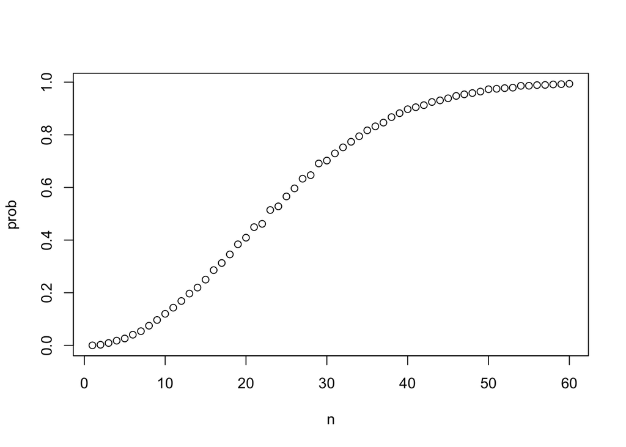

```r
prob <- sapply(n, compute_prob)    # element-wise application of compute_prob to n
plot(n, prob)
```

*Computing birthday problem probabilities with sapply*

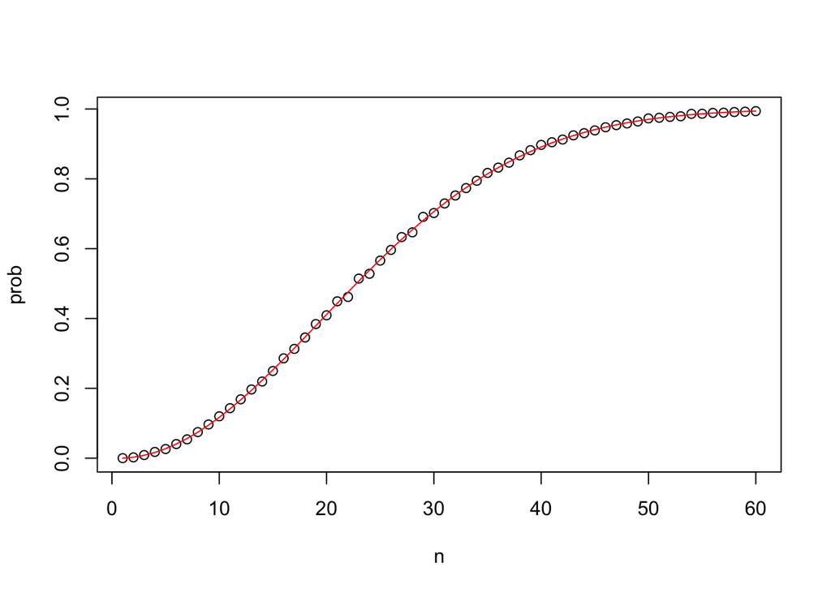

```r
# function for computing exact probability of shared birthdays for any n
exact_prob <- function(n){
    prob_unique <- seq(365, 365-n+1)/365   # vector of fractions for mult. rule
    1 - prod(prob_unique)    # calculate prob of no shared birthdays and subtract from 1
}

# applying function element-wise to vector of n values
eprob <- sapply(n, exact_prob)

# plotting Monte Carlo results and exact probabilities on same graph
plot(n, prob)    # plot Monte Carlo results
lines(n, eprob, col = "red")    # add line for exact prob
```

## How many Monte Carlo Experiments are enough?

Here is a link to the [matching textbook section](https://rafalab.github.io/dsbook/probability.html#infinity-in-practice).

**Key points**

- The larger the number of Monte Carlo replicates $B$, the more accurate the estimate.
- Determining the appropriate size for $B$ can require advanced statistics.
- One practical approach is to try many sizes for $B$ and look for sizes that provide stable estimates.

*Code: Estimating a practical value of B*

This code runs Monte Carlo simulations to estimate the probability of shared birthdays using several **B** values and plots the results. When **B** is large enough that the estimated probability stays stable, then we have selected a useful value of **B**.

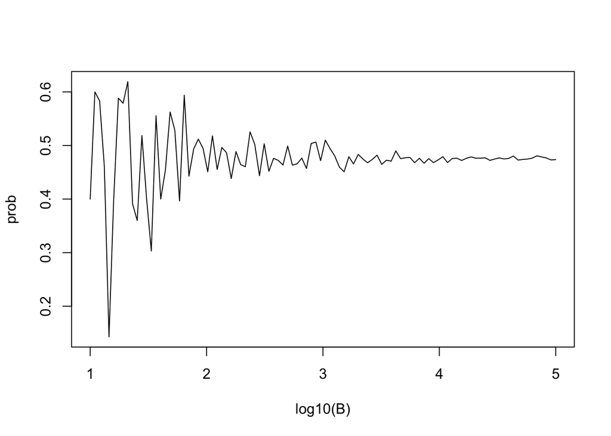

```r
B <- 10^seq(1, 5, len = 100)    # defines vector of many B values
compute_prob <- function(B, n = 22){    # function to run Monte Carlo simulation with each B
    same_day <- replicate(B, {
        bdays <- sample(1:365, n, replace = TRUE)
        any(duplicated(bdays))
    })
    mean(same_day)
}
prob <- sapply(B, compute_prob)    # apply compute_prob to many values of B
plot(log10(B), prob, type = "l")    # plot a line graph of estimates
```

## Assessment - Combinations and Permutations

1.Imagine you draw two balls from a box containing colored balls. You either replace the first ball before you draw the second or you leave the first ball out of the box when you draw the second ball.

Under which situation are the two draws independent of one another?

Remember that two events A and B are independent if:

$\mbox{Pr}(\text{A and B}) = \mbox{Pr}(A)P(B)$

- A. You don’t replace the first ball before drawing the next.
- B. You do replace the first ball before drawing the next.
- C. Neither situation describes independent events.
- D. Both situations describe independent events.
2. Say you’ve drawn 5 balls from the a box that has 3 cyan balls, 5 magenta balls, and 7 yellow balls, with replacement, and all have been yellow.

What is the probability that the next one is yellow?

```r
# Assign the variable 'p_yellow' as the probability that a yellow ball is drawn from the box.
p_yellow <- yellow / (cyan + magenta + yellow)

# Using the variable 'p_yellow', calculate the probability of drawing a yellow ball on the sixth draw. Print this value to the console.
p_yellow
```

```
## [1] 0.4666667
```

3. If you roll a 6-sided die once, what is the probability of not seeing a 6? If you roll a 6-sided die six times, what is the probability of not seeing a 6 on any roll?

```r
# Assign the variable 'p_no6' as the probability of not seeing a 6 on a single roll.
p_no6 <- 5/6

# Calculate the probability of not seeing a 6 on six rolls using `p_no6`. Print your result to the console: do not assign it to a variable.
p_no6*p_no6*p_no6*p_no6*p_no6*p_no6
```

```
## [1] 0.334898
```

4. Two teams, say the Celtics and the Cavs, are playing a seven game series. The Cavs are a better team and have a 60% chance of winning each game.

What is the probability that the Celtics win at least one game? Remember that the Celtics must win one of the first four games, or the series will be over!

```r
# Assign the variable `p_cavs_win4` as the probability that the Cavs will win the first four games of the series.
p_cavs_win4 <- (3/5)*(3/5)*(3/5)*(3/5)

# Using the variable `p_cavs_win4`, calculate the probability that the Celtics win at least one game in the first four games of the series.
1-p_cavs_win4
```

```
## [1] 0.8704
```

5. Create a Monte Carlo simulation to confirm your answer to the previous problem by estimating how frequently the Celtics win at least 1 of 4 games. Use `B <- 10000` simulations.

The provided sample code simulates a single series of four random games, `simulated_games`

```r
# This line of example code simulates four independent random games where the Celtics either lose or win. Copy this example code to use within the `replicate` function.
simulated_games <- sample(c("lose","win"), 4, replace = TRUE, prob = c(0.6, 0.4))

# The variable 'B' specifies the number of times we want the simulation to run. Let's run the Monte Carlo simulation 10,000 times.
B <- 10000

# Use the `set.seed` function to make sure your answer matches the expected result after random sampling.
set.seed(1)

# Create an object called `celtic_wins` that replicates two steps for B iterations: (1) generating a random four-game series `simulated_games` using the example code, then (2) determining whether the simulated series contains at least one win for the Celtics.
celtic_wins <- replicate(B, {
  simulated_games <- sample(c("lose","win"), 4, replace = TRUE, prob = c(0.6, 0.4))
  any(simulated_games=="win")}
)

# Calculate the frequency out of B iterations that the Celtics won at least one game. Print your answer to the console.
mean(celtic_wins)
```

```
## [1] 0.8757
```

## The Addition rule

Here is a link to the textbook section on the [addition rule](https://rafalab.github.io/dsbook/probability.html#addition-rule).

**Key points**

- The addition rule states that the probability of event $A$ or event $B$ happening is the probability of event $A$ plus the probability of event $B$ minus the probability of both events $A$ and $B$ happening together.

$\mbox{Pr}(\text{A or B})=\mbox{Pr}(A) + \mbox{Pr}(B) − \mbox{Pr}(\text{A and B})$

Note that $(\text{A or B})$ is equivalent to $(A \mid B)$.

*Example: The addition rule for a natural 21 in blackjack*

We apply the addition rule where $A$ = drawing an ace then a facecard and $B$ = drawing a facecard then an ace. Note that in this case, both events A and B cannot happen at the same time, so $\mbox{Pr}(\text{A and B}) = 0$.

$\mbox{Pr}(\text{ace then facecard}) = \frac{4}{52}\:X\: \frac{16}{51}$

$\mbox{Pr}(\text{facecard then ace}) = \frac{16}{52}\:X\: \frac{4}{51}$

$\mbox{Pr}(\text{ace then facecard} \mid \text{facecard then ace}) = \frac{4}{52}\:X\: \frac{16}{51} + \frac{16}{52}\:X\: \frac{4}{51} = 0.0483$

## The Monty Hall Problem

Here is the textbook section on the [Monty Hall Problem](https://rafalab.github.io/dsbook/probability.html#monty-hall-problem).

*Key points*

- Monte Carlo simulations can be used to simulate random outcomes, which makes them useful when exploring ambiguous or less intuitive problems like the Monty Hall problem.
- In the Monty Hall problem, contestants choose one of three doors that may contain a prize. Then, one of the doors that was not chosen by the contestant and does not contain a prize is revealed. The contestant can then choose whether to stick with the original choice or switch to the remaining unopened door.
- Although it may seem intuitively like the contestant has a 1 in 2 chance of winning regardless of whether they stick or switch, Monte Carlo simulations demonstrate that the actual probability of winning is 1 in 3 with the stick strategy and 2 in 3 with the switch strategy.
- For more on the Monty Hall problem, you can [watch a detailed explanation here](https://www.khanacademy.org/math/precalculus/prob-comb/dependent-events-precalc/v/monty-hall-problem) or [read an explanation here](https://en.wikipedia.org/wiki/Monty_Hall_problem).

*Code: Monte Carlo simulation of stick strategy*

```r
B <- 10000
stick <- replicate(B, {
  doors <- as.character(1:3)
  prize <- sample(c("car","goat","goat"))    # puts prizes in random order
  prize_door <- doors[prize == "car"]    # note which door has prize
  my_pick  <- sample(doors, 1)    # note which door is chosen
  show <- sample(doors[!doors %in% c(my_pick, prize_door)],1)    # open door with no prize that isn't chosen
  stick <- my_pick    # stick with original door
  stick == prize_door    # test whether the original door has the prize
})
mean(stick)    # probability of choosing prize door when sticking
```

```
## [1] 0.3388
```

*Code: Monte Carlo simulation of switch strategy*

```r
switch <- replicate(B, {
  doors <- as.character(1:3)
  prize <- sample(c("car","goat","goat"))    # puts prizes in random order
  prize_door <- doors[prize == "car"]    # note which door has prize
  my_pick  <- sample(doors, 1)    # note which door is chosen first
  show <- sample(doors[!doors %in% c(my_pick, prize_door)], 1)    # open door with no prize that isn't chosen
  switch <- doors[!doors%in%c(my_pick, show)]    # switch to the door that wasn't chosen first or opened
  switch == prize_door    # test whether the switched door has the prize
})
mean(switch)    # probability of choosing prize door when switching
```

```
## [1] 0.6708
```

## Assessment - The Addition Rule and Monty Hall

1. Two teams, say the Cavs and the Warriors, are playing a seven game championship series. The first to win four games wins the series. The teams are equally good, so they each have a 50-50 chance of winning each game.

If the Cavs lose the first game, what is the probability that they win the series?

```r
# Assign a variable 'n' as the number of remaining games.
n <-6

# Assign a variable `outcomes` as a vector of possible game outcomes, where 0 indicates a loss and 1 indicates a win for the Cavs.
outcomes <- (0:1)

# Assign a variable `l` to a list of all possible outcomes in all remaining games. Use the `rep` function on `list(outcomes)` to create list of length `n`.
l <- rep(list(outcomes), n)

# Create a data frame named 'possibilities' that contains all combinations of possible outcomes for the remaining games.
possibilities <- expand.grid(l)

# Create a vector named 'results' that indicates whether each row in the data frame 'possibilities' contains enough wins for the Cavs to win the series.
results <- rowSums(possibilities)>=4

# Calculate the proportion of 'results' in which the Cavs win the series. Print the outcome to the console.
mean(results)
```

```
## [1] 0.34375
```

2. Confirm the results of the previous question with a Monte Carlo simulation to estimate the probability of the Cavs winning the series after losing the first game.

```r
# The variable `B` specifies the number of times we want the simulation to run. Let's run the Monte Carlo simulation 10,000 times.
B <- 10000

# Use the `set.seed` function to make sure your answer matches the expected result after random sampling.
set.seed(1)

# Create an object called `results` that replicates for `B` iterations a simulated series and determines whether that series contains at least four wins for the Cavs.
results <- replicate(B, {
  cavs_wins <- sample(c(0,1), 6, replace = TRUE)
  sum(cavs_wins)>=4 }
)

# Calculate the frequency out of `B` iterations that the Cavs won at least four games in the remainder of the series. Print your answer to the console.
mean(results)
```

```
## [1] 0.3371
```

3. Two teams, $A$ and $B$, are playing a seven series game series. Team $A$ is better than team $B$ and has a `p > 0.5` chance of winning each game.

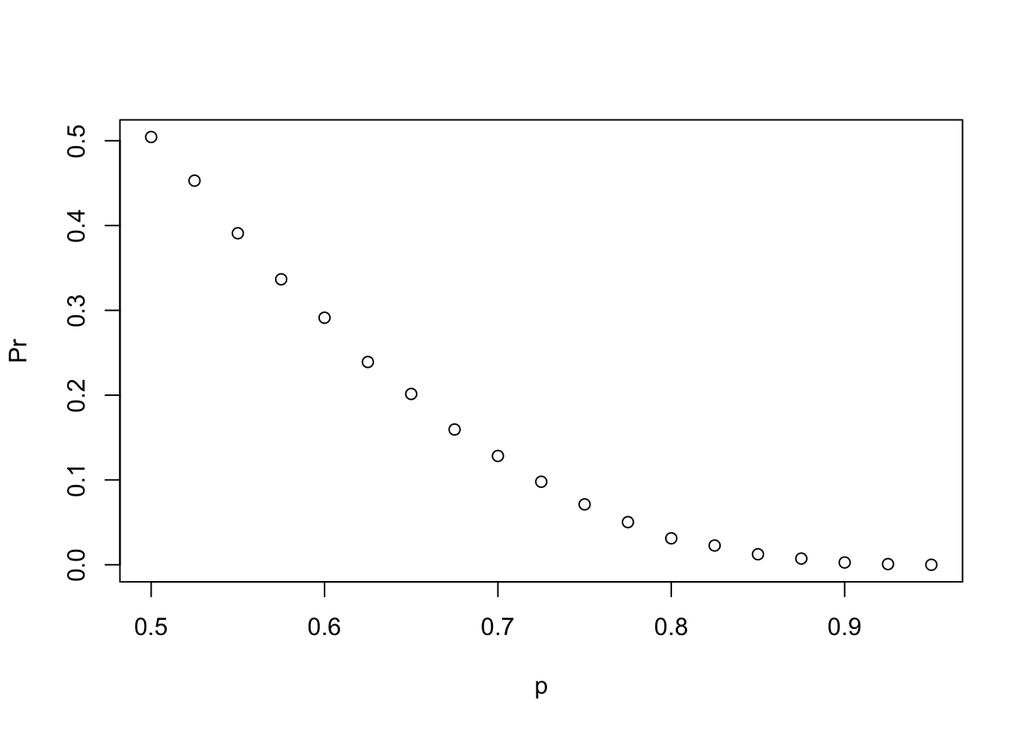

```r
# Let's assign the variable 'p' as the vector of probabilities that team A will win.
p <- seq(0.5, 0.95, 0.025)

# Given a value 'p', the probability of winning the series for the underdog team B can be computed with the following function based on a Monte Carlo simulation:
prob_win <- function(p){
  B <- 10000
  result <- replicate(B, {
    b_win <- sample(c(1,0), 7, replace = TRUE, prob = c(1-p, p))
    sum(b_win)>=4
    })
  mean(result)
}

# Apply the 'prob_win' function across the vector of probabilities that team A will win to determine the probability that team B will win. Call this object 'Pr'.
Pr <- sapply(p, prob_win)

# Plot the probability 'p' on the x-axis and 'Pr' on the y-axis.
plot(p,Pr)
```

4. Repeat the previous exercise, but now keep the probability that team $A$ wins fixed at `p <- 0.75` and compute the probability for different series lengths.

For example, wins in best of 1 game, 3 games, 5 games, and so on through a series that lasts 25 games.

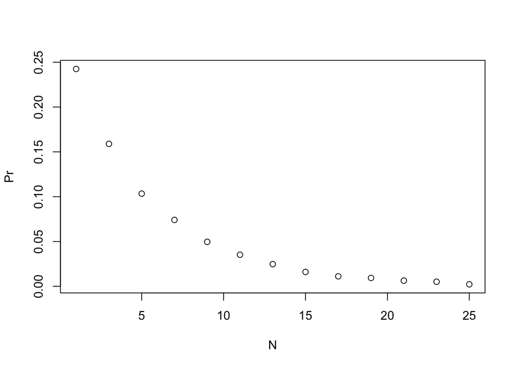

```r
# Given a value 'p', the probability of winning the series for the underdog team B can be computed with the following function based on a Monte Carlo simulation:
prob_win <- function(N, p=0.75){
      B <- 10000
      result <- replicate(B, {
        b_win <- sample(c(1,0), N, replace = TRUE, prob = c(1-p, p))
        sum(b_win)>=(N+1)/2
        })
      mean(result)
    }

# Assign the variable 'N' as the vector of series lengths. Use only odd numbers ranging from 1 to 25 games.
N <- seq(1, 25, 2)

# Apply the 'prob_win' function across the vector of series lengths to determine the probability that team B will win. Call this object `Pr`.
Pr <- sapply(N, prob_win)

# Plot the number of games in the series 'N' on the x-axis and 'Pr' on the y-axis.
plot(N,Pr)
```

## Assessment - Olympic Running

```r
if(!require(tidyverse)) install.packages("tidyverse")
library(tidyverse)
options(digits = 3)    # report 3 significant digits
```

1. In the 200m dash finals in the Olympics, 8 runners compete for 3 medals (order matters). In the 2012 Olympics, 3 of the 8 runners were from Jamaica and the other 5 were from different countries. The three medals were all won by Jamaica (Usain Bolt, Yohan Blake, and Warren Weir).

Use the information above to help you answer the following four questions.

1a. How many different ways can the 3 medals be distributed across 8 runners?

```r
medals <- permutations(8,3)
nrow(medals)
```

```
## [1] 336
```

1b. How many different ways can the three medals be distributed among the 3 runners from Jamaica?

```r
jamaica <- permutations(3,3)
nrow(jamaica)
```

```
## [1] 6
```

1c. What is the probability that all 3 medals are won by Jamaica?

```r
nrow(jamaica)/nrow(medals)
```

```
## [1] 0.0179
```

1d. Run a Monte Carlo simulation on this vector representing the countries of the 8 runners in this race:

```r
runners <- c("Jamaica", "Jamaica", "Jamaica", "USA", "Ecuador", "Netherlands", "France", "South Africa")
```

For each iteration of the Monte Carlo simulation, within a `replicate` loop, select 3 runners representing the 3 medalists and check whether they are all from Jamaica. Repeat this simulation 10,000 times. Set the seed to 1 before running the loop.

Calculate the probability that all the runners are from Jamaica.

```r
set.seed(1)
runners <- c("Jamaica", "Jamaica", "Jamaica", "USA", "Ecuador", "Netherlands", "France", "South Africa")
B <- 10000
all_jamaica <- replicate(B, {
  results <- sample(runners, 3)
  all(results == "Jamaica")
})
mean(all_jamaica)
```

```
## [1] 0.0174
```

## Assessment - Restaurant Management

2: Use the information below to answer the following five questions.

A restaurant manager wants to advertise that his lunch special offers enough choices to eat different meals every day of the year. He doesn’t think his current special actually allows that number of choices, but wants to change his special if needed to allow at least 365 choices.

A meal at the restaurant includes 1 entree, 2 sides, and 1 drink. He currently offers a choice of 1 entree from a list of 6 options, a choice of 2 different sides from a list of 6 options, and a choice of 1 drink from a list of 2 options.

2a. How many meal combinations are possible with the current menu?

```r
6 * nrow(combinations(6,2)) * 2
```

```
## [1] 180
```

2b. The manager has one additional drink he could add to the special.

How many combinations are possible if he expands his original special to 3 drink options?

```r
6 * nrow(combinations(6,2)) * 3
```

```
## [1] 270
```

2c. The manager decides to add the third drink but needs to expand the number of options. The manager would prefer not to change his menu further and wants to know if he can meet his goal by letting customers choose more sides.

How many meal combinations are there if customers can choose from 6 entrees, 3 drinks, and select 3 sides from the current 6 options?

```r
6 * nrow(combinations(6,3)) * 3
```

```
## [1] 360
```

2d. The manager is concerned that customers may not want 3 sides with their meal. He is willing to increase the number of entree choices instead, but if he adds too many expensive options it could eat into profits. He wants to know how many entree choices he would have to offer in order to meet his goal.

- Write a function that takes a number of entree choices and returns the number of meal combinations possible given that number of entree options, 3 drink choices, and a selection of 2 sides from 6 options.
- Use `sapply` to apply the function to entree option counts ranging from 1 to 12.

What is the minimum number of entree options required in order to generate more than 365 combinations?

```r
entree_choices <- function(x){
  x * nrow(combinations(6,2)) * 3
}

combos <- sapply(1:12, entree_choices)

data.frame(entrees = 1:12, combos = combos) %>%
  filter(combos > 365) %>%
  min(.$entrees)
```

```
## [1] 9
```

2e. The manager isn’t sure he can afford to put that many entree choices on the lunch menu and thinks it would be cheaper for him to expand the number of sides. He wants to know how many sides he would have to offer to meet his goal of at least 365 combinations.

- Write a function that takes a number of side choices and returns the number of meal combinations possible given 6 entree choices, 3 drink choices, and a selection of 2 sides from the specified number of side choices.
- Use `sapply` to apply the function to side counts ranging from 2 to 12.

What is the minimum number of side options required in order to generate more than 365 combinations?

```r
side_choices <- function(x){
  6 * nrow(combinations(x, 2)) * 3
}

combos <- sapply(2:12, side_choices)

data.frame(sides = 2:12, combos = combos) %>%
  filter(combos > 365) %>%
  min(.$sides)
```

```
## [1] 7
```

## Assessment - Esophageal cancer and alcohol/tobacco use

3., 4., 5. and 6. Case-control studies help determine whether certain exposures are associated with outcomes such as developing cancer. The built-in dataset **esoph** contains data from a case-control study in France comparing people with esophageal cancer (cases, counted in **ncases**) to people without esophageal cancer (controls, counted in **ncontrols**) that are carefully matched on a variety of demographic and medical characteristics. The study compares alcohol intake in grams per day (**alcgp**) and tobacco intake in grams per day (**tobgp**) across cases and controls grouped by age range (**agegp**).

The dataset is available in base R and can be called with the variable name **esoph**:

```r
head(esoph)
```

```
##   agegp     alcgp    tobgp ncases ncontrols
## 1 25-34 0-39g/day 0-9g/day      0        40
## 2 25-34 0-39g/day    10-19      0        10
## 3 25-34 0-39g/day    20-29      0         6
## 4 25-34 0-39g/day      30+      0         5
## 5 25-34     40-79 0-9g/day      0        27
## 6 25-34     40-79    10-19      0         7
```

You will be using this dataset to answer the following four multi-part questions (Questions 3-6).

You may wish to use the tidyverse package.

The following three parts have you explore some basic characteristics of the dataset.

Each row contains one group of the experiment. Each group has a different combination of age, alcohol consumption, and tobacco consumption. The number of cancer cases and number of controls (individuals without cancer) are reported for each group.

3a. How many groups are in the study?

```r
nrow(esoph)
```

```
## [1] 88
```

3b. How many cases are there?

Save this value as `all_cases` for later problems.

```r
all_cases <- sum(esoph$ncases)
all_cases
```

```
## [1] 200
```

3c. How many controls are there?

Save this value as `all_controls` for later problems. Remember from the instructions that controls are individuals without cancer.

```r
all_controls <- sum(esoph$ncontrols)
all_controls
```

```
## [1] 975
```

4a. What is the probability that a subject in the highest alcohol consumption group is a cancer case?

Remember that the total number of individuals in the study includes people with cancer (cases) and people without cancer (controls), so you must add both values together to get the denominator for your probability.

```r
esoph %>%
  filter(alcgp == "120+") %>%
  summarize(ncases = sum(ncases), ncontrols = sum(ncontrols)) %>%
  mutate(p_case = ncases / (ncases + ncontrols)) %>%
  pull(p_case)
```

```
## [1] 0.402
```

4b. What is the probability that a subject in the lowest alcohol consumption group is a cancer case?

```r
esoph %>%
  filter(alcgp == "0-39g/day") %>%
  summarize(ncases = sum(ncases), ncontrols = sum(ncontrols)) %>%
  mutate(p_case = ncases / (ncases + ncontrols)) %>%
  pull(p_case)
```

```
## [1] 0.0653
```

4c. Given that a person is a case, what is the probability that they smoke 10g or more a day?

```r
tob_cases <- esoph %>%
  filter(tobgp != "0-9g/day") %>%
  pull(ncases) %>%
  sum()

tob_cases/all_cases
```

```
## [1] 0.61
```

4d. Given that a person is a control, what is the probability that they smoke 10g or more a day?

```r
tob_controls <- esoph %>%
  filter(tobgp != "0-9g/day") %>%
  pull(ncontrols) %>%
  sum()

tob_controls/all_controls
```

```
## [1] 0.462
```

5a. For cases, what is the probability of being in the highest alcohol group?

```r
high_alc_cases <- esoph %>%
  filter(alcgp == "120+") %>%
  pull(ncases) %>%
  sum()

p_case_high_alc <- high_alc_cases/all_cases
p_case_high_alc
```

```
## [1] 0.225
```

5b. For cases, what is the probability of being in the highest tobacco group?

```r
high_tob_cases <- esoph %>%
  filter(tobgp == "30+") %>%
  pull(ncases) %>%
  sum()

p_case_high_tob <- high_tob_cases/all_cases
p_case_high_tob
```

```
## [1] 0.155
```

5c. For cases, what is the probability of being in the highest alcohol group **and** the highest tobacco group?

```r
high_alc_tob_cases <- esoph %>%
  filter(alcgp == "120+" & tobgp == "30+") %>%
  pull(ncases) %>%
  sum()

p_case_high_alc_tob <- high_alc_tob_cases/all_cases
p_case_high_alc_tob
```

```
## [1] 0.05
```

5d. For cases, what is the probability of being in the highest alcohol group **or** the highest tobacco group?

```r
p_case_either_highest <- p_case_high_alc + p_case_high_tob - p_case_high_alc_tob
p_case_either_highest
```

```
## [1] 0.33
```

6a. For controls, what is the probability of being in the highest alcohol group?

```r
high_alc_controls <- esoph %>%
  filter(alcgp == "120+") %>%
  pull(ncontrols) %>%
  sum()

p_control_high_alc <- high_alc_controls/all_controls
p_control_high_alc
```

```
## [1] 0.0687
```

6b. How many times more likely are cases than controls to be in the highest alcohol group?

```r
p_case_high_alc/p_control_high_alc
```

```
## [1] 3.27
```

6c. For controls, what is the probability of being in the highest tobacco group?

```r
high_tob_controls <- esoph %>%
  filter(tobgp == "30+") %>%
  pull(ncontrols) %>%
  sum()

p_control_high_tob <- high_tob_controls/all_controls
p_control_high_tob
```

```
## [1] 0.0841
```

6d. For controls, what is the probability of being in the highest alcohol group **and** the highest tobacco group?

```r
high_alc_tob_controls <- esoph %>%
  filter(alcgp == "120+" & tobgp == "30+") %>%
  pull(ncontrols) %>%
  sum()

p_control_high_alc_tob <- high_alc_tob_controls/all_controls
p_control_high_alc_tob
```

```
## [1] 0.0133
```

6e. For controls, what is the probability of being in the highest alcohol group **or** the highest tobacco group?

```r
p_control_either_highest <- p_control_high_alc + p_control_high_tob - p_control_high_alc_tob
p_control_either_highest
```

```
## [1] 0.139
```

6f. How many times more likely are cases than controls to be in the highest alcohol group or the highest tobacco group?

```r
p_case_either_highest/p_control_either_highest
```

```
## [1] 2.37
```

# Section 2 Overview

Section 2 introduces you to Continuous Probability.

After completing Section 2, you will:

- understand the differences between calculating probabilities for discrete and continuous data.
- be able to use cumulative distribution functions to assign probabilities to intervals when dealing with continuous data.
- be able to use R to generate normally distributed outcomes for use in Monte Carlo simulations.
- know some of the useful theoretical continuous distributions in addition to the normal distribution, such as the student-t, chi-squared, exponential, gamma, beta, and beta-binomial distributions.

## Continuous Probability

The textbook for this section is available [here](https://rafalab.github.io/dsbook/probability.html#continuous-probability).

The previous discussion of CDF is from the Data Visualization course. Here is the [textbook section on the CDF](https://rafalab.github.io/dsbook/distributions.html#cdf-intro).

**Key points**

- The *cumulative distribution function (CDF)* is a distribution function for continuous data $x$ that reports the proportion of the data below $a$ for all values of $a$:

$F(a) = \mbox{Pr}(a) = \mbox{Pr}(x \le a)$

- The CDF is the *probability distribution function* for continuous variables. For example, to determine the probability that a male student is taller than 70.5 inches given a vector of male heights $x$, we can use the CDF:

$\mbox{Pr}(x > 70.5) = 1 − \mbox{Pr}(x \le 70.5) = 1 − F(70.5)$

- The probability that an observation is in between two values $a, b$ is $F(b) - F(a)$.

*Code: Cumulative distribution function*

Define **x** as male heights from the **dslabs** dataset:

```r
if(!require(dslabs)) install.packages("dslabs")
library(dslabs)
data(heights)
x <- heights %>% filter(sex=="Male") %>% pull(height)
```

Given a vector **x**, we can define a function for computing the CDF of **x** using:

```r
F <- function(a) mean(x <= a)

1 - F(70)    # probability of male taller than 70 inches
```

```
## [1] 0.377
```

## Theoretical Distribution

The textbook for this section is available [here](https://rafalab.github.io/dsbook/probability.html#theoretical-continuous-distributions).

**Key points**

- **pnorm(a, avg, s)** gives the value of the cumulative distribution function $F(a)$ for the normal distribution defined by average **avg** and standard deviation **s**.
- We say that a random quantity is normally distributed with average **avg** and standard deviation **s** if the approximation **pnorm(a, avg, s)** holds for all values of **a**.
- If we are willing to use the normal approximation for height, we can estimate the distribution simply from the mean and standard deviation of our values.
- If we treat the height data as discrete rather than categorical, we see that the data are not very useful because integer values are more common than expected due to rounding. This is called *discretization*.
- With rounded data, the normal approximation is particularly useful when computing probabilities of intervals of length 1 that include exactly one integer.

*Code: Using **pnorm** to calculate probabilities*

Given male heights **x**:

```r
x <- heights %>% filter(sex=="Male") %>% pull(height)
```

We can estimate the probability that a male is taller than 70.5 inches using:

```r
1 - pnorm(70.5, mean(x), sd(x))
```

```
## [1] 0.371
```

*Code: Discretization and the normal approximation*

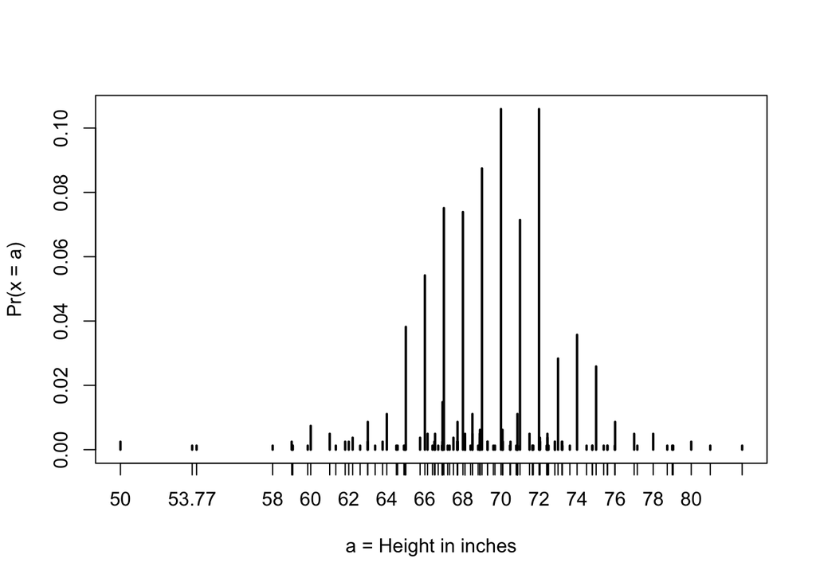

```r
# plot distribution of exact heights in data
plot(prop.table(table(x)), xlab = "a = Height in inches", ylab = "Pr(x = a)")
```

```r
# probabilities in actual data over length 1 ranges containing an integer
mean(x <= 68.5) - mean(x <= 67.5)
```

```
## [1] 0.115
```

```r
mean(x <= 69.5) - mean(x <= 68.5)
```

```
## [1] 0.119
```

```r
mean(x <= 70.5) - mean(x <= 69.5)
```

```
## [1] 0.122
```

```r
# probabilities in normal approximation match well
pnorm(68.5, mean(x), sd(x)) - pnorm(67.5, mean(x), sd(x))
```

```
## [1] 0.103
```

```r
pnorm(69.5, mean(x), sd(x)) - pnorm(68.5, mean(x), sd(x))
```

```
## [1] 0.11
```

```r
pnorm(70.5, mean(x), sd(x)) - pnorm(69.5, mean(x), sd(x))
```

```
## [1] 0.108
```

```r
# probabilities in actual data over other ranges don't match normal approx as well
mean(x <= 70.9) - mean(x <= 70.1)
```

```
## [1] 0.0222
```

```r
pnorm(70.9, mean(x), sd(x)) - pnorm(70.1, mean(x), sd(x))
```

```
## [1] 0.0836
```

## Probability Density

The textbook for this section is available [here](https://rafalab.github.io/dsbook/probability.html#the-probability-density).

**Key points**

- The probability of a single value is not defined for a continuous distribution.
- The quantity with the most similar interpretation to the probability of a single value is the probability density function $f(x)$.
- The probability density $f(x)$ is defined such that the integral of $f(x)$ over a range gives the CDF of that range.

$F(a) = \mbox{Pr}(X \le a) = \int_{-\infty}^{a} f(x)dx$

- In R, the probability density function for the normal distribution is given by **dnorm**. We will see uses of **dnorm** in the future.
- Note that **dnorm** gives the density function and **pnorm** gives the distribution function, which is the integral of the density function.

## Monte Carlo simulations

The textbook for this section is available [here](https://rafalab.github.io/dsbook/probability.html#monte-carlo-simulations-for-continuous-variables).

**Key points**

- **rnorm(n, avg, s)** generates **n** random numbers from the normal distribution with average **avg** and standard deviation **s**.
- By generating random numbers from the normal distribution, we can simulate height data with similar properties to our dataset. Here we generate simulated height data using the normal distribution.

*Code: Generating normally distributed random numbers for Monte Carlo simulations*

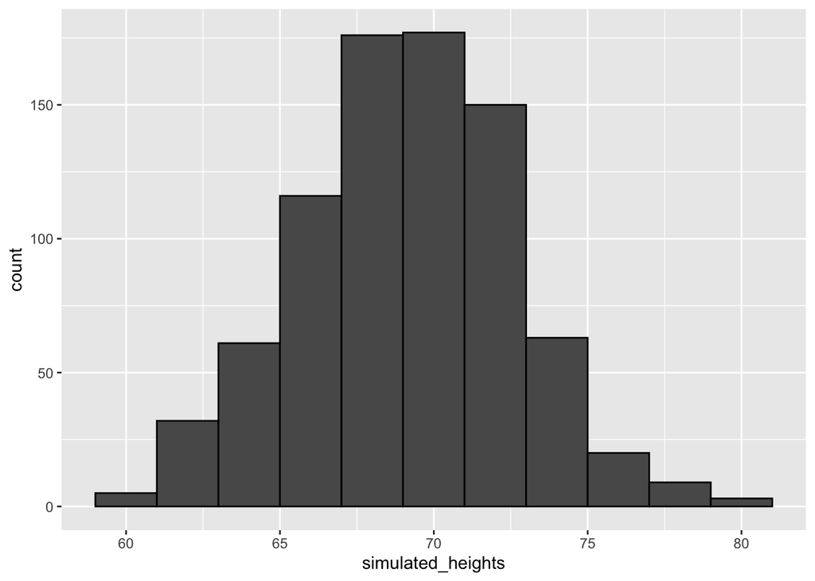

```r
# define x as male heights from dslabs data
library(tidyverse)
library(dslabs)
data(heights)
x <- heights %>% filter(sex=="Male") %>% pull(height)

# generate simulated height data using normal distribution - both datasets should have n observations
n <- length(x)
avg <- mean(x)
s <- sd(x)
simulated_heights <- rnorm(n, avg, s)

# plot distribution of simulated_heights
data.frame(simulated_heights = simulated_heights) %>%
    ggplot(aes(simulated_heights)) +
    geom_histogram(color="black", binwidth = 2)
```

*Code: Monte Carlo simulation of probability of tallest person being over 7 feet*

```r
B <- 10000
tallest <- replicate(B, {
    simulated_data <- rnorm(800, avg, s)    # generate 800 normally distributed random heights
    max(simulated_data)    # determine the tallest height
})
mean(tallest >= 7*12)    # proportion of times that tallest person exceeded 7 feet (84 inches)
```

```
## [1] 0.0209
```

## Other Continuous Distributions

The textbook for this section is available [here](https://rafalab.github.io/dsbook/probability.html#continuous-distributions).

**Key points**

- You may encounter other continuous distributions (Student t, chi-squared, exponential, gamma, beta, etc.).
- R provides functions for density (**d**), quantile (**q**), probability distribution (**p**) and random number generation (**r**) for many of these distributions.
- Each distribution has a matching abbreviation (for example, **norm** or **t**) that is paired with the related function abbreviations (**d, p, q, r**) to create appropriate functions.
- For example, use **rt** to generate random numbers for a Monte Carlo simulation using the Student t distribution.

*Code: Plotting the normal distribution with dnorm*

Use d to plot the density function of a continuous distribution. Here is the density function for the normal distribution (abbreviation norm):

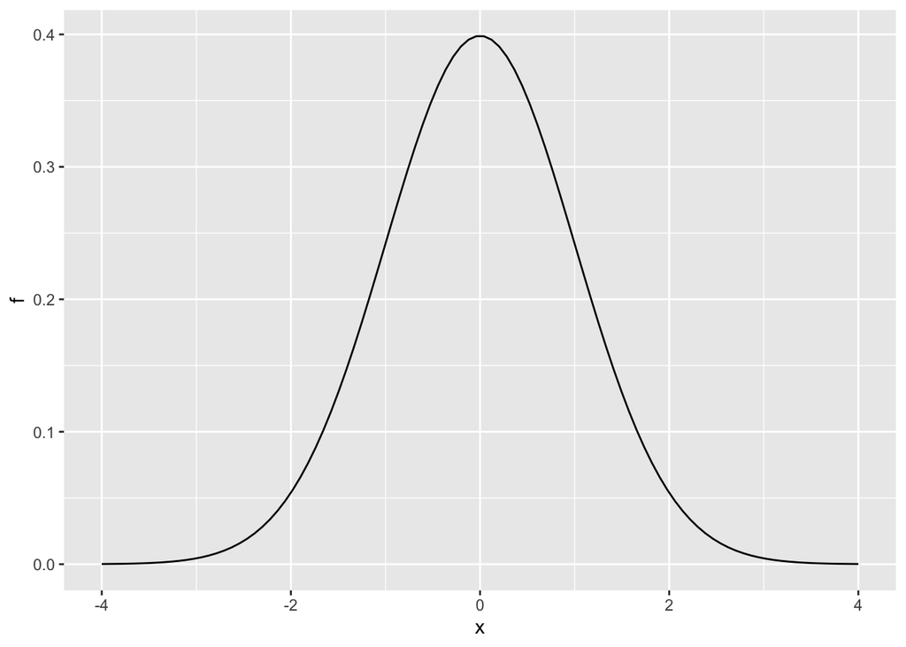

```r
x <- seq(-4, 4, length.out = 100)
data.frame(x, f = dnorm(x)) %>%
    ggplot(aes(x,f)) +
    geom_line()
```

## Assessment - Continuous Probability

1. Assume the distribution of female heights is approximated by a normal distribution with a mean of 64 inches and a standard deviation of 3 inches.

If we pick a female at random, what is the probability that she is 5 feet or shorter?

```r
# Assign a variable 'female_avg' as the average female height.
female_avg <- 64

# Assign a variable 'female_sd' as the standard deviation for female heights.
female_sd <- 3

# Using variables 'female_avg' and 'female_sd', calculate the probability that a randomly selected female is shorter than 5 feet. Print this value to the console.
pnorm((5*12), female_avg, female_sd)
```

```
## [1] 0.0912
```

2. Assume the distribution of female heights is approximated by a normal distribution with a mean of 64 inches and a standard deviation of 3 inches.

If we pick a female at random, what is the probability that she is 6 feet or taller?

```r
# Assign a variable 'female_avg' as the average female height.
female_avg <- 64

# Assign a variable 'female_sd' as the standard deviation for female heights.
female_sd <- 3

# Using variables 'female_avg' and 'female_sd', calculate the probability that a randomly selected female is 6 feet or taller. Print this value to the console.
1-pnorm((6*12), female_avg, female_sd)
```

```
## [1] 0.00383
```

3. Assume the distribution of female heights is approximated by a normal distribution with a mean of 64 inches and a standard deviation of 3 inches.

If we pick a female at random, what is the probability that she is between 61 and 67 inches?

```r
# Assign a variable 'female_avg' as the average female height.
female_avg <- 64

# Assign a variable 'female_sd' as the standard deviation for female heights.
female_sd <- 3

# Using variables 'female_avg' and 'female_sd', calculate the probability that a randomly selected female is between the desired height range. Print this value to the console.
pnorm(67, female_avg, female_sd) - pnorm(61, female_avg, female_sd)
```

```
## [1] 0.683
```

4. Repeat the previous exercise, but convert everything to centimeters.

That is, multiply every height, including the standard deviation, by 2.54. What is the answer now?

```r
# Assign a variable 'female_avg' as the average female height. Convert this value to centimeters.
female_avg <- 64*2.54

# Assign a variable 'female_sd' as the standard deviation for female heights. Convert this value to centimeters.
female_sd <- 3*2.54

# Using variables 'female_avg' and 'female_sd', calculate the probability that a randomly selected female is between the desired height range. Print this value to the console.
pnorm((67*2.54), female_avg, female_sd) - pnorm((61*2.54), female_avg, female_sd)
```

```
## [1] 0.683
```

5. Compute the probability that the height of a randomly chosen female is within 1 SD from the average height.

```r
# Assign a variable 'female_avg' as the average female height.
female_avg <- 64

# Assign a variable 'female_sd' as the standard deviation for female heights.
female_sd <- 3

# To a variable named 'taller', assign the value of a height that is one SD taller than average.
taller <- female_avg + female_sd

# To a variable named 'shorter', assign the value of a height that is one SD shorter than average.
shorter <- female_avg - female_sd

# Calculate the probability that a randomly selected female is between the desired height range. Print this value to the console.
pnorm(taller, female_avg, female_sd) - pnorm(shorter, female_avg, female_sd)
```

```
## [1] 0.683
```

6. Imagine the distribution of male adults is approximately normal with an expected value of 69 inches and a standard deviation of 3 inches.

How tall is a male in the 99th percentile?

```r
# Assign a variable 'male_avg' as the average male height.
male_avg <- 69

# Assign a variable 'male_sd' as the standard deviation for male heights.
male_sd <- 3

# Determine the height of a man in the 99th percentile of the distribution.
qnorm(0.99, male_avg, male_sd)
```

```
## [1] 76
```

7. The distribution of IQ scores is approximately normally distributed.

The average is 100 and the standard deviation is 15. Suppose you want to know the distribution of the person with the highest IQ in your school district, where 10,000 people are born each year.

Generate 10,000 IQ scores 1,000 times using a Monte Carlo simulation. Make a histogram of the highest IQ scores.

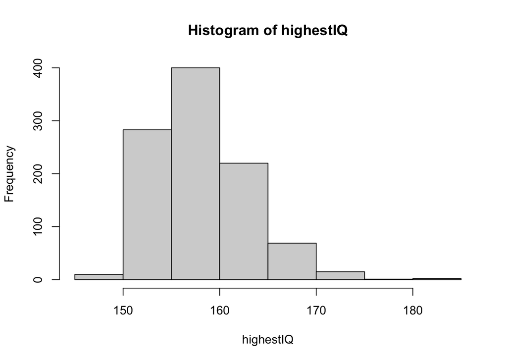

```r
# The variable `B` specifies the number of times we want the simulation to run.
B <- 1000

# Use the `set.seed` function to make sure your answer matches the expected result after random number generation.
set.seed(1)

# Create an object called `highestIQ` that contains the highest IQ score from each random distribution of 10,000 people.
highestIQ <- replicate(B, {
    IQ <- rnorm(10000, 100, 15)
    max(IQ)
})

# Make a histogram of the highest IQ scores.
hist(highestIQ)
```

## Assessment - ACT scores, part 1

1. and 2. The ACT is a standardized college admissions test used in the United States. The four multi-part questions in this assessment all involve simulating some ACT test scores and answering probability questions about them.

For the three year period 2016-2018, [ACT standardized test scores](http://www.act.org/content/act/en/products-and-services/the-act/scores/national-ranks.html) were approximately normally distributed with a mean of 20.9 and standard deviation of 5.7. (Real ACT scores are integers between 1 and 36, but we will ignore this detail and use continuous values instead.)

First we’ll simulate an ACT test score dataset and answer some questions about it.

Set the seed to 16, then use **rnorm** to generate a normal distribution of 10000 tests with a mean of 20.9 and standard deviation of 5.7. Save these values as **act_scores**. You’ll be using this dataset throughout these four multi-part questions.

**(IMPORTANT NOTE! If you use R 3.6 or later, you will need to use the command set.seed(x, sample.kind = “Rounding”) instead of set.seed(x). Your R version will be printed at the top of the Console window when you start RStudio.)**

1a. What is the mean of `act_scores`?

```r
set.seed(16, sample.kind = "Rounding")
act_scores <- rnorm(10000, 20.9, 5.7)
mean(act_scores)
```

```
## [1] 20.8
```

1b. What is the standard deviation of `act_scores`?

```r
sd(act_scores)
```

```
## [1] 5.68
```

1c. A perfect score is 36 or greater (the maximum reported score is 36).

In `act_scores`, how many perfect scores are there out of 10,000 simulated tests?

```r
sum(act_scores >= 36)
```

```
## [1] 41
```

1d. In `act_scores`, what is the probability of an ACT score greater than 30?

```r
mean(act_scores > 30)
```

```
## [1] 0.0527
```

1e. In `act_scores`, what is the probability of an ACT score less than or equal to 10?

```r
mean(act_scores <= 10)
```

```
## [1] 0.0282
```

2. Set `x` equal to the sequence of integers 1 to 36. Use `dnorm` to determine the value of the probability density function over `x` given a mean of 20.9 and standard deviation of 5.7; save the result as `f_x`. Plot `x` against `f_x`.

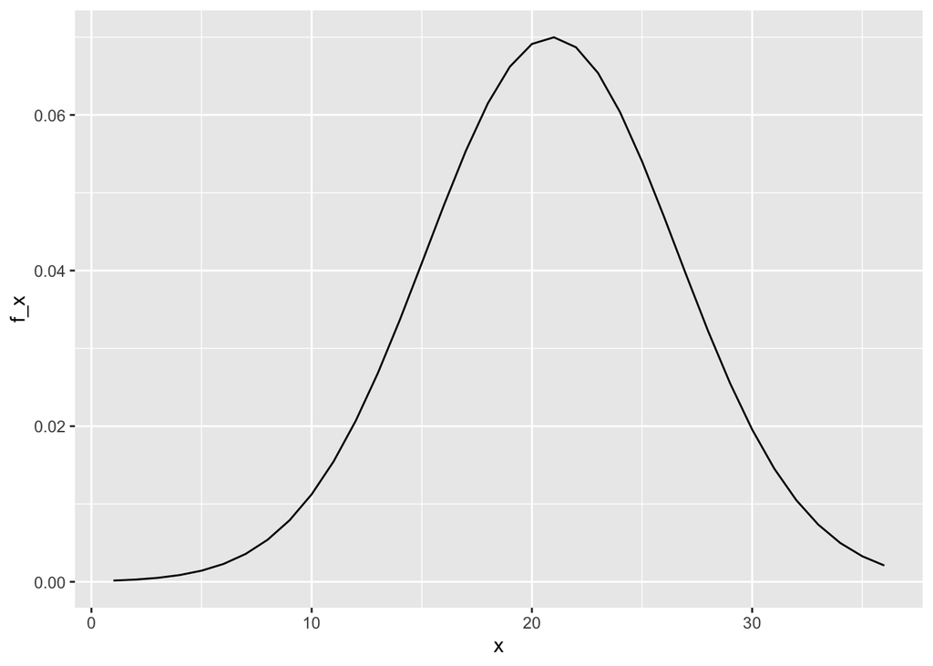

```r
x <- 1:36
f_x <- dnorm(x, 20.9, 5.7)
data.frame(x, f_x) %>%
  ggplot(aes(x, f_x)) +
  geom_line()
```

Which of the following plots is correct?

- B.

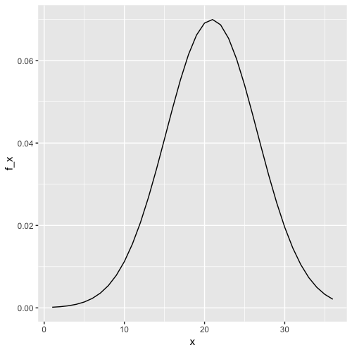

Plot x against f_x

## Assessment - ACT scores, part 2

3. In this 3-part question, you will convert raw ACT scores to Z-scores and answer some questions about them.

Convert **act_scores** to Z-scores. Recall from [Data Visualization](https://www.edx.org/course/data-science-visualization) (the second course in this series) that to standardize values (convert values into Z-scores, that is, values distributed with a mean of 0 and standard deviation of 1), you must subtract the mean and then divide by the standard deviation. Use the mean and standard deviation of **act_scores**, not the original values used to generate random test scores.

3a. What is the probability of a Z-score greater than 2 (2 standard deviations above the mean)?

```r
z_scores <- (act_scores - mean(act_scores))/sd(act_scores)
mean(z_scores > 2)
```

```
## [1] 0.0233
```

3b. What ACT score value corresponds to 2 standard deviations above the mean (Z = 2)?

```r
2*sd(act_scores) + mean(act_scores)
```

```
## [1] 32.2
```

3c. A Z-score of 2 corresponds roughly to the 97.5th percentile.

Use `qnorm` to determine the 97.5th percentile of normally distributed data with the mean and standard deviation observed in `act_scores`.

What is the 97.5th percentile of `act_scores`?

```r
qnorm(.975, mean(act_scores), sd(act_scores))
```

```
## [1] 32
```

4. In this 4-part question, you will write a function to create a CDF for ACT scores.

Write a function that takes a value and produces the probability of an ACT score less than or equal to that value (the CDF). Apply this function to the range 1 to 36.

4a. What is the minimum integer score such that the probability of that score or lower is at least .95?

Your answer should be an integer 1-36.

```r
cdf <- sapply(1:36, function (x){
  mean(act_scores <= x)
})
min(which(cdf >= .95))
```

```
## [1] 31
```

4b. Use qnorm to determine the expected 95th percentile, the value for which the probability of receiving that score or lower is 0.95, given a mean score of 20.9 and standard deviation of 5.7.

What is the expected 95th percentile of ACT scores?

```r
qnorm(.95, 20.9, 5.7)
```

```
## [1] 30.3
```

4c. As discussed in the Data Visualization course, we can use `quantile` to determine sample quantiles from the data.

Make a vector containing the quantiles for `p <- seq(0.01, 0.99, 0.01)`, the 1st through 99th percentiles of the `act_scores` data. Save these as `sample_quantiles`.

In what percentile is a score of 26?

Note that a score between the 98th and 99th percentile should be considered the 98th percentile, for example, and that quantile numbers are used as names for the vector `sample_quantiles`.

```r
p <- seq(0.01, 0.99, 0.01)
sample_quantiles <- quantile(act_scores, p)
names(sample_quantiles[max(which(sample_quantiles < 26))])
```

```
## [1] "82%"
```

4d. Make a corresponding set of theoretical quantiles using `qnorm` over the interval `p <- seq(0.01, 0.99, 0.01)` with mean 20.9 and standard deviation 5.7. Save these as `theoretical_quantiles`. Make a QQ-plot graphing `sample_quantiles` on the y-axis versus `theoretical_quantiles` on the x-axis.

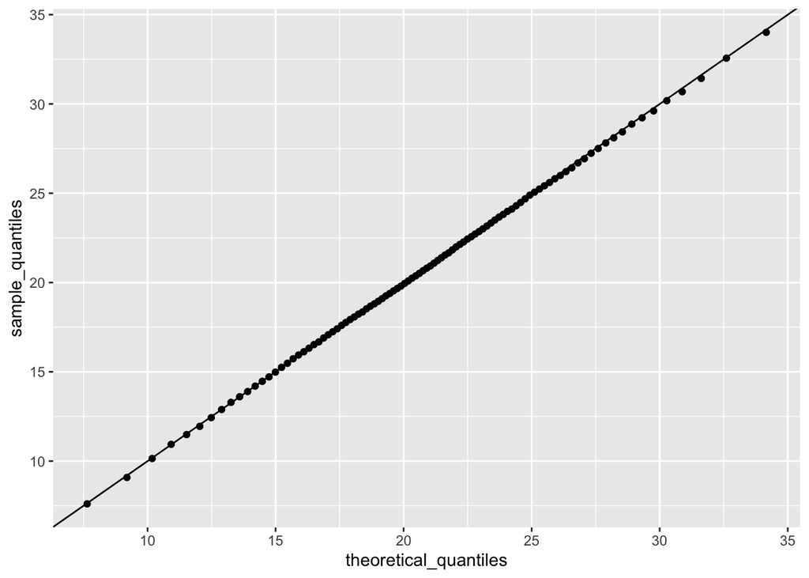

```r
p <- seq(0.01, 0.99, 0.01)
sample_quantiles <- quantile(act_scores, p)
theoretical_quantiles <- qnorm(p, 20.9, 5.7)
qplot(theoretical_quantiles, sample_quantiles) + geom_abline()
```

Which of the following graphs is correct?

- D.

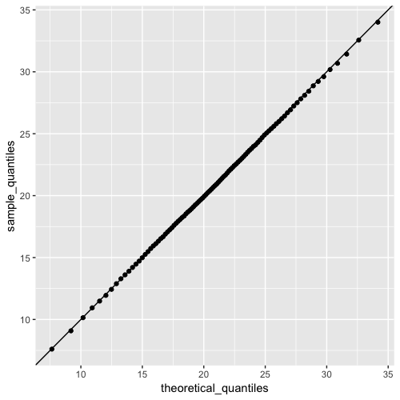

Sample quantiles versus Theoretical quantiles

# Section 3 Overview

Section 3 introduces you to Random Variables, Sampling Models, and the Central Limit Theorem.

Section 3 is divided into two parts:

- Random Variables and Sampling Models
- The Central Limit Theorem.

After completing Section 3, you will:

- understand what random variables are, how to generate them, and the correct mathematical notation to use with them.
- be able to use sampling models to estimate characteristics of a larger population.
- be able to explain the difference between a distribution and a probability distribution.
- understand the Central Limit Theorem and the law of large numbers.

## Random variables

The textbook for this section is available [here](https://rafalab.github.io/dsbook/random-variables.html#random-variables-1).

**Key points**

- Random variables are numeric outcomes resulting from random processes.
- Statistical inference offers a framework for quantifying uncertainty due to randomness.

*Code: Modeling a random variable*

```r
# define random variable x to be 1 if blue, 0 otherwise
beads <- rep(c("red", "blue"), times = c(2, 3))
x <- ifelse(sample(beads, 1) == "blue", 1, 0)

# demonstrate that the random variable is different every time
ifelse(sample(beads, 1) == "blue", 1, 0)
```

```
## [1] 0
```

```r
ifelse(sample(beads, 1) == "blue", 1, 0)
```

```
## [1] 1
```

```r
ifelse(sample(beads, 1) == "blue", 1, 0)
```

```
## [1] 1
```

## Sampling Models

The textbook for this section is available [here](https://rafalab.github.io/dsbook/random-variables.html#sampling-models).

**Key points**

- A sampling model models the random behavior of a process as the sampling of draws from an urn.
- The **probability distribution of a random variable** is the probability of the observed value falling in any given interval.
- We can define a CDF $F(a) = \mbox{Pr}(S \le a)$ to answer questions related to the probability of S being in any interval.
- The average of many draws of a random variable is called its **expected value**.
- The standard deviation of many draws of a random variable is called its **standard error**.

*Monte Carlo simulation: Chance of casino losing money on roulette*

We build a sampling model for the random variable $S$ that represents the casino’s total winnings.

```r
# sampling model 1: define urn, then sample
color <- rep(c("Black", "Red", "Green"), c(18, 18, 2)) # define the urn for the sampling model
n <- 1000
X <- sample(ifelse(color == "Red", -1, 1), n, replace = TRUE)    # 1000 draws from urn, -1 if red, else +1
X[1:10]    # first 10 outcomes
```

```
##  [1]  1  1 -1 -1 -1  1  1 -1  1  1
```

```r
# sampling model 2: define urn inside sample function by noting probabilities
x <- sample(c(-1, 1), n, replace = TRUE, prob = c(9/19, 10/19))    # 1000 independent draws
S <- sum(x)    # total winnings = sum of draws
S
```

```
## [1] 74
```

We use the sampling model to run a Monte Carlo simulation and use the results to estimate the probability of the casino losing money.

```r
n <- 1000    # number of roulette players
B <- 10000    # number of Monte Carlo experiments
S <- replicate(B, {
    X <- sample(c(-1,1), n, replace = TRUE, prob = c(9/19, 10/19))    # simulate 1000 roulette spins
    sum(X)    # determine total profit
})

mean(S < 0)    # probability of the casino losing money
```

```
## [1] 0.0447
```

We can plot a histogram of the observed values of S as well as the normal density curve based on the mean and standard deviation of S.

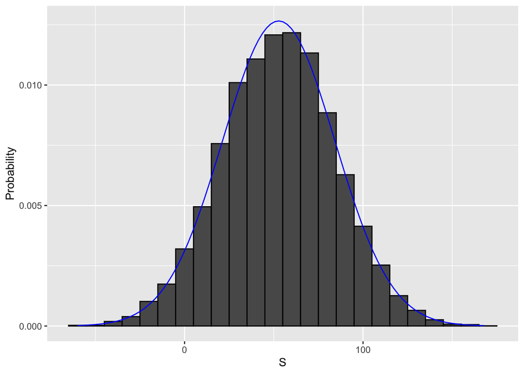

```r
s <- seq(min(S), max(S), length = 100)    # sequence of 100 values across range of S
normal_density <- data.frame(s = s, f = dnorm(s, mean(S), sd(S))) # generate normal density for S
data.frame (S = S) %>%    # make data frame of S for histogram
    ggplot(aes(S, ..density..)) +
    geom_histogram(color = "black", binwidth = 10) +
    ylab("Probability") +
    geom_line(data = normal_density, mapping = aes(s, f), color = "blue")
```

## Distributions versus Probability Distributions

The textbook for this section is available [here](https://rafalab.github.io/dsbook/random-variables.html#distributions-versus-probability-distributions).

**Key points**

- A random variable $X$ has a probability distribution function $F(a)$ that defines $\mbox{Pr}(X \le a)$ over all values of $a$.
- Any list of numbers has a distribution. The probability distribution function of a random variable is defined mathematically and does not depend on a list of numbers.
- The results of a Monte Carlo simulation with a large enough number of observations will approximate the probability distribution of $X$.
- If a random variable is defined as draws from an urn:
  - The probability distribution function of the random variable is defined as the distribution of the list of values in the urn.
  - The expected value of the random variable is the average of values in the urn.
  - The standard error of one draw of the random variable is the standard deviation of the values of the urn.

## Notation for Random Variables

The textbook for this section is available [here](https://rafalab.github.io/dsbook/random-variables.html#notation-for-random-variables).

**Key points**

- Capital letters denote random variables ($X$) and lowercase letters denote observed values ($x$).
- In the notation $\mbox{Pr}(X = x)$, we are asking how frequently the random variable $X$ is equal to the value $x$. For example, if $x = 6$, this statement becomes $\mbox{Pr}(X = 6)$.

## Central Limit Theorem (CLT)

The textbook for this section is available [here](https://rafalab.github.io/dsbook/random-variables.html#the-expected-value-and-standard-error) and [here](https://rafalab.github.io/dsbook/random-variables.html#central-limit-theorem).

**Key points**

- The Central Limit Theorem (CLT) says that the distribution of the sum of a random variable is approximated by a normal distribution.
- The expected value of a random variable, $E \left [ X \right] = \mu$, is the average of the values in the urn. This represents the expectation of one draw.
- The standard error of one draw of a random variable is the standard deviation of the values in the urn.
- The expected value of the sum of draws is the number of draws times the expected value of the random variable.
- The standard error of the sum of independent draws of a random variable is the square root of the number of draws times the standard deviation of the urn.

*Equations*

These equations apply to the case where there are only two outcomes, $a$ and $b$ with proportions $p$ and $1-p$ respectively. The general principles above also apply to random variables with more than two outcomes.

Expected value of a random variable:

$ap + b(1-p)$

Expected value of the sum of n draws of a random variable:

$n$ x $(ap + b(1-p))$

Standard deviation of an urn with two values:

$|b-a|\sqrt{p(1-p)}$

Standard error of the sum of n draws of a random variable:

$\sqrt n$ x $|b-a|\sqrt{p(1-p)}$

## Assessment - Random Variables and Sampling Models

1. An American roulette wheel has 18 red, 18 black, and 2 green pockets.

Each red and black pocket is associated with a number from 1 to 36. The two remaining green slots feature “0” and “00”. Players place bets on which pocket they think a ball will land in after the wheel is spun. Players can bet on a specific number (0, 00, 1-36) or color (red, black, or green).

What are the chances that the ball lands in a green pocket?

```r
# The variables `green`, `black`, and `red` contain the number of pockets for each color
green <- 2
black <- 18
red <- 18

# Assign a variable `p_green` as the probability of the ball landing in a green pocket
p_green <- 2/(2+18+18)

# Print the variable `p_green` to the console
p_green
```

```
## [1] 0.0526
```

2. In American roulette, the payout for winning on green is $17.

This means that if you bet $1 and it lands on green, you get $17 as a prize.

Create a model to predict your winnings from betting on green one time.

```r
# Use the `set.seed` function to make sure your answer matches the expected result after random sampling.
set.seed(1)

# The variables 'green', 'black', and 'red' contain the number of pockets for each color
green <- 2
black <- 18
red <- 18

# Assign a variable `p_green` as the probability of the ball landing in a green pocket
p_green <- green / (green+black+red)

# Assign a variable `p_not_green` as the probability of the ball not landing in a green pocket
p_not_green = 1 - p_green


# Create a model to predict the random variable `X`, your winnings from betting on green. Sample one time.
X <- sample(c(-1,17), 1, replace = TRUE, prob = c(p_not_green, p_green))

# Print the value of `X` to the console
X
```

```
## [1] -1
```

3. In American roulette, the payout for winning on green is $17.

This means that if you bet $1 and it lands on green, you get $17 as a prize. In the previous exercise, you created a model to predict your winnings from betting on green.

Now, compute the expected value of $X$, the random variable you generated previously.

```r
# The variables 'green', 'black', and 'red' contain the number of pockets for each color
green <- 2
black <- 18
red <- 18

# Assign a variable `p_green` as the probability of the ball landing in a green pocket
p_green <- green / (green+black+red)

# Assign a variable `p_not_green` as the probability of the ball not landing in a green pocket
p_not_green <- 1-p_green

# Calculate the expected outcome if you win $17 if the ball lands on green and you lose $1 if the ball doesn't land on green
17 * p_green + (-1 * p_not_green)
```

```
## [1] -0.0526
```

4. The standard error of a random variable $X$ tells us the difference between a random variable and its expected value. You calculated a random variable $X$ in exercise 2 and the expected value of that random variable in exercise 3.

Now, compute the standard error of that random variable, which represents a single outcome after one spin of the roulette wheel.

```r
# The variables 'green', 'black', and 'red' contain the number of pockets for each color
green <- 2
black <- 18
red <- 18

# Assign a variable `p_green` as the probability of the ball landing in a green pocket
p_green <- green / (green+black+red)

# Assign a variable `p_not_green` as the probability of the ball not landing in a green pocket
p_not_green <- 1-p_green

# Compute the standard error of the random variable
abs((17 - -1))*sqrt(p_green*p_not_green)
```

```
## [1] 4.02
```

5. You modeled the outcome of a single spin of the roulette wheel, $X$, in exercise 2.

Now create a random variable $S$ that sums your winnings after betting on green 1,000 times.

```r
# The variables 'green', 'black', and 'red' contain the number of pockets for each color
green <- 2
black <- 18
red <- 18

# Assign a variable `p_green` as the probability of the ball landing in a green pocket
p_green <- green / (green+black+red)

# Assign a variable `p_not_green` as the probability of the ball not landing in a green pocket
p_not_green <- 1-p_green

# Use the `set.seed` function to make sure your answer matches the expected result after random sampling
set.seed(1)

# Define the number of bets using the variable 'n'
n <- 1000

# Create a vector called 'X' that contains the outcomes of 1000 samples
X <- sample(c(-1,17), n, replace = TRUE, prob = c(p_not_green, p_green))

# Assign the sum of all 1000 outcomes to the variable 'S'
S <- sum(X)

# Print the value of 'S' to the console
S
```

```
## [1] -10
```

6. In the previous exercise, you generated a vector of random outcomes, $S$, after betting on green 1,000 times.

What is the expected value of $S$?

```r
# The variables 'green', 'black', and 'red' contain the number of pockets for each color
green <- 2
black <- 18
red <- 18

# Assign a variable `p_green` as the probability of the ball landing in a green pocket
p_green <- green / (green+black+red)

# Assign a variable `p_not_green` as the probability of the ball not landing in a green pocket
p_not_green <- 1-p_green

# Define the number of bets using the variable 'n'
n <- 1000

# Calculate the expected outcome of 1,000 spins if you win $17 when the ball lands on green and you lose $1 when the ball doesn't land on green
n * (17 * p_green + (-1 * p_not_green))
```

```
## [1] -52.6
```

7. You generated the expected value of $S$, the outcomes of 1,000 bets that the ball lands in the green pocket, in the previous exercise.

What is the standard error of $S$?

```r
# The variables 'green', 'black', and 'red' contain the number of pockets for each color
green <- 2
black <- 18
red <- 18

# Assign a variable `p_green` as the probability of the ball landing in a green pocket
p_green <- green / (green+black+red)

# Assign a variable `p_not_green` as the probability of the ball not landing in a green pocket
p_not_green <- 1-p_green

# Define the number of bets using the variable 'n'
n <- 1000

# Compute the standard error of the sum of 1,000 outcomes
sqrt(n) * abs((17 - -1))*sqrt(p_green*p_not_green)
```

```
## [1] 127
```

## Averages and Proportions

The textbook for this section is available [here](https://rafalab.github.io/dsbook/random-variables.html#statistical-properties-of-averages).

**Key points**

- Random variable times a constant

The *expected value of a random variable multiplied by a constant* is that constant times its original expected value:

$E \left [aX \right ] = a \mu$

The *standard error of a random variable multiplied by a constant* is that constant times its original standard error:

$SE \left [aX \right ] = a \sigma$

- Average of multiple draws of a random variable

The *expected value of average of multiple draws* from an urn is the expected value of the urn ($\mu$).

The *standard deviation of the average of multiple draws* from an urn is the standard deviation of the urn divided by the square root of the number of draws ($\sigma / \sqrt{n}$).

- The sum of multiple draws of a random variable

The *expected value of the sum of $n$ draws of random variable* is $n$ times its original expected value:

$E \left [nX \right ] = n \mu$

The *standard error of the sum of $n$ draws of random variable* is $\sqrt{n}$ times its original standard error:

$SE \left [nX \right ] = \sqrt{n \sigma}$

- The sum of multiple different random variables

The *expected value of the sum of different random variables* is the sum of the individual expected values for each random variable:

$E \left [X_1 + X_2 + ... + X_n \right ] = \mu_1 + \mu_2 + ... + \mu_n$

The *standard error of the sum of different random variables* is the square root of the sum of squares of the individual standard errors:

$SE \left [X_1 + X_2 + ... + X_n \right ] = \sqrt{\sigma_1^2 + \sigma_2^2 + ... + \sigma_n^2}$

- Transformation of random variables

If $X$ is a normally distributed random variable and $a$ and $b$ are non-random constants, then $aX + b$ is also a normally distributed random variable.

## Law of Large Numbers

The textbook for this section is available [here](https://rafalab.github.io/dsbook/random-variables.html#law-of-large-numbers).

**Key points**

- The law of large numbers states that as $n$ increases, the standard error of the average of a random variable decreases. In other words, when $n$ is large, the average of the draws converges to the average of the urn.
- The law of large numbers is also known as the law of averages.
- The law of averages only applies when $n$ is very large and events are independent. It is often misused to make predictions about an event being “due” because it has happened less frequently than expected in a small sample size.

## How Large is Large in CLT?

The textbook for this section is available [here](https://rafalab.github.io/dsbook/random-variables.html#how-large-is-large-in-the-central-limit-theorem).

You can read more about the Poisson distribution at [this link](https://en.wikipedia.org/wiki/Poisson_distribution).

**Key points**

- The sample size required for the Central Limit Theorem and Law of Large Numbers to apply differs based on the probability of success.
  - If the probability of success is high, then relatively few observations are needed.
  - As the probability of success decreases, more observations are needed.
- If the probability of success is extremely low, such as winning a lottery, then the Central Limit Theorem may not apply even with extremely large sample sizes. The normal distribution is not a good approximation in these cases, and other distributions such as the Poisson distribution (not discussed in these courses) may be more appropriate.

## Assessment - The Central Limit Theorem

1. The exercises in the previous chapter explored winnings in American roulette.

In this chapter of exercises, we will continue with the roulette example and add in the Central Limit Theorem.

In the previous chapter of exercises, you created a random variable $S$ that is the sum of your winnings after betting on green a number of times in American Roulette.

What is the probability that you end up winning money if you bet on green 100 times?

```r
# Assign a variable `p_green` as the probability of the ball landing in a green pocket
p_green <- 2 / 38

# Assign a variable `p_not_green` as the probability of the ball not landing in a green pocket
p_not_green <- 1-p_green

# Define the number of bets using the variable 'n'
n <- 100

# Calculate 'avg', the expected outcome of 100 spins if you win $17 when the ball lands on green and you lose $1 when the ball doesn't land on green
avg <- n * (17*p_green + -1*p_not_green)

# Compute 'se', the standard error of the sum of 100 outcomes
se <- sqrt(n) * (17 - -1)*sqrt(p_green*p_not_green)

# Using the expected value 'avg' and standard error 'se', compute the probability that you win money betting on green 100 times.
1-pnorm(0,avg,se)
```

```
## [1] 0.448
```

2. Create a Monte Carlo simulation that generates 10,000 outcomes of $S$, the sum of 100 bets.

Compute the average and standard deviation of the resulting list and compare them to the expected value (-5.263158) and standard error (40.19344) for $S$ that you calculated previously.

```r
# Assign a variable `p_green` as the probability of the ball landing in a green pocket
p_green <- 2 / 38

# Assign a variable `p_not_green` as the probability of the ball not landing in a green pocket
p_not_green <- 1-p_green

# Define the number of bets using the variable 'n'
n <- 100

# The variable `B` specifies the number of times we want the simulation to run. Let's run the Monte Carlo simulation 10,000 times.
B <- 10000

# Use the `set.seed` function to make sure your answer matches the expected result after random sampling.
set.seed(1)

# Create an object called `S` that replicates the sample code for `B` iterations and sums the outcomes.
S <- replicate(B,{
   X <- sample(c(17,-1), size = n, replace = TRUE, prob = c(p_green, p_not_green))
   sum(X)
   })

# Compute the average value for 'S'
mean(S)
```

```
## [1] -5.91
```

```r
# Calculate the standard deviation of 'S'
sd(S)
```

```
## [1] 40.3
```

3. In this chapter, you calculated the probability of winning money in American roulette using the CLT.

Now, calculate the probability of winning money from the Monte Carlo simulation. The Monte Carlo simulation from the previous exercise has already been pre-run for you, resulting in the variable $S$ that contains a list of 10,000 simulated outcomes.

```r
# Calculate the proportion of outcomes in the vector `S` that exceed $0
mean(S > 0)
```

```
## [1] 0.423
```

4. The Monte Carlo result and the CLT approximation for the probability of losing money after 100 bets are close, but not that close. What could account for this?
- A. 10,000 simulations is not enough. If we do more, the estimates will match.
- B. The CLT does not work as well when the probability of success is small.
- C. The difference is within rounding error.
- D. The CLT only works for the averages.
5. Now create a random variable $Y$ that contains your average winnings per bet after betting on green 10,000 times.

```r
# Use the `set.seed` function to make sure your answer matches the expected result after random sampling.
set.seed(1)

# Define the number of bets using the variable 'n'
n <- 10000

# Assign a variable `p_green` as the probability of the ball landing in a green pocket
p_green <- 2 / 38

# Assign a variable `p_not_green` as the probability of the ball not landing in a green pocket
p_not_green <- 1 - p_green

# Create a vector called `X` that contains the outcomes of `n` bets
X <- sample(c(-1,17), n, replace = TRUE, prob = c(p_not_green, p_green))

# Define a variable `Y` that contains the mean outcome per bet. Print this mean to the console.
Y <- mean(X)
Y
```

```
## [1] 0.008
```

6. What is the expected value of $Y$, the average outcome per bet after betting on green 10,000 times?

```r
# Assign a variable `p_green` as the probability of the ball landing in a green pocket
p_green <- 2 / 38

# Assign a variable `p_not_green` as the probability of the ball not landing in a green pocket
p_not_green <- 1 - p_green

# Calculate the expected outcome of `Y`, the mean outcome per bet in 10,000 bets
Y <- p_green * 17 + p_not_green * -1
Y
```

```
## [1] -0.0526
```

7. What is the standard error of $Y$, the average result of 10,000 spins?

```r
# Define the number of bets using the variable 'n'
n <- 10000

# Assign a variable `p_green` as the probability of the ball landing in a green pocket
p_green <- 2 / 38

# Assign a variable `p_not_green` as the probability of the ball not landing in a green pocket
p_not_green <- 1 - p_green

# Compute the standard error of 'Y', the mean outcome per bet from 10,000 bets.
Y <- abs((17 - -1))*sqrt(p_green*p_not_green) / sqrt(n)
Y
```

```
## [1] 0.0402
```

8. What is the probability that your winnings are positive after betting on green 10,000 times?

```r
# We defined the average using the following code
avg <- 17*p_green + -1*p_not_green

# We defined standard error using this equation
se <- 1/sqrt(n) * (17 - -1)*sqrt(p_green*p_not_green)

# Given this average and standard error, determine the probability of winning more than $0. Print the result to the console.
1-pnorm(0,avg,se)
```

```
## [1] 0.0952
```

9. Create a Monte Carlo simulation that generates 10,000 outcomes of $S$, the average outcome from 10,000 bets on green.

Compute the average and standard deviation of the resulting list to confirm the results from previous exercises using the Central Limit Theorem.

```r
## Make sure you fully follow instructions, including printing values to the console and correctly running the `replicate` loop. If not, you may encounter "Session Expired" errors.

# The variable `n` specifies the number of independent bets on green
n <- 10000

# The variable `B` specifies the number of times we want the simulation to run
B <- 10000

# Use the `set.seed` function to make sure your answer matches the expected result after random number generation
set.seed(1)

# Generate a vector `S` that contains the the average outcomes of 10,000 bets modeled 10,000 times
S <- replicate(B,{
  X <- sample(c(17,-1), size = n, replace = TRUE, prob = c(p_green, p_not_green))
  mean(X)
})

# Compute the average of `S`
mean(S)
```

```
## [1] -0.0522
```

```r
# Compute the standard deviation of `S`
sd(S)
```

```
## [1] 0.04
```

10. In a previous exercise, you found the probability of winning more than $0 after betting on green 10,000 times using the Central Limit Theorem.

Then, you used a Monte Carlo simulation to model the average result of betting on green 10,000 times over 10,000 simulated series of bets.

What is the probability of winning more than $0 as estimated by your Monte Carlo simulation? The code to generate the vector $S$ that contains the the average outcomes of 10,000 bets modeled 10,000 times has already been run for you.

```r
# Compute the proportion of outcomes in the vector 'S' where you won more than $0
mean(S>0)
```

```
## [1] 0.0977
```

11. The Monte Carlo result and the CLT approximation are now much closer than when we calculated the probability of winning for 100 bets on green. What could account for this difference?
- A. We are now computing averages instead of sums.
- B. 10,000 Monte Carlo simulations was not enough to provide a good estimate.
- C. The CLT works better when the sample size is larger.
- D. It is not closer. The difference is within rounding error.

## Assessment - SAT Testing

1. and 2. The SAT is a standardized college admissions test used in the United States. The following two multi-part questions will ask you some questions about SAT testing.

This is a 6-part question asking you to determine some probabilities of what happens when a student guessed for all of their answers on the SAT. Use the information below to inform your answers for the following questions.

An old version of the SAT college entrance exam had a -0.25 point penalty for every incorrect answer and awarded 1 point for a correct answer. The quantitative test consisted of 44 multiple-choice questions each with 5 answer choices. Suppose a student chooses answers by guessing for all questions on the test.

1a. What is the probability of guessing correctly for one question?

```r
p <- 1/5 # one correct choice of 5 options
p
```

```
## [1] 0.2
```

1b. What is the expected value of points for guessing on one question?

```r
a <- 1
b <- -0.25
mu <- a*p + b*(1-p)
mu
```

```
## [1] 0
```

1c. What is the expected score of guessing on all 44 questions?

```r
n <- 44
n*mu
```

```
## [1] 0
```

1d. What is the standard error of guessing on all 44 questions?

```r
sigma <- sqrt(n) * abs(b-a) * sqrt(p*(1-p))
sigma
```

```
## [1] 3.32
```

1e. Use the Central Limit Theorem to determine the probability that a guessing student scores 8 points or higher on the test.

```r
1-pnorm(8, mu, sigma)
```

```
## [1] 0.00793
```

1f. Set the seed to 21, then run a Monte Carlo simulation of 10,000 students guessing on the test.

(IMPORTANT! If you use R 3.6 or later, you will need to use the command `set.seed(x, sample.kind = "Rounding")` instead of `set.seed(x)`. Your R version will be printed at the top of the Console window when you start RStudio.)

What is the probability that a guessing student scores 8 points or higher?

```r
set.seed(21, sample.kind = "Rounding")
B <- 10000
n <- 44
p <- 0.2
tests <- replicate(B, {
  X <- sample(c(1, -0.25), n, replace = TRUE, prob = c(p, 1-p))
  sum(X)
})
mean(tests >= 8)
```

```
## [1] 0.008
```

The SAT was recently changed to reduce the number of multiple choice options from 5 to 4 and also to eliminate the penalty for guessing.

In this three-part question, you’ll explore how that affected the expected values for the test.

2a. Suppose that the number of multiple choice options is 4 and that there is no penalty for guessing - that is, an incorrect question gives a score of 0.

What is the expected value of the score when guessing on this new test?

```r
p <- 1/4
a <- 1
b <- 0
n <- 44
mu <- n * a*p + b*(1-p)
mu
```

```
## [1] 11
```

2b. Using the normal approximation, what is the estimated probability of scoring over 30 when guessing?

Report your answer using scientific notation with 3 significant digits in the format `x.xx*10^y`. Do not round the values passed to `pnorm` or you will lose precision and have an incorrect answer.

```r
sigma <- sqrt(n) * abs(b-a) * sqrt(p*(1-p))
1-pnorm(30, mu, sigma)
```

```
## [1] 1.86e-11
```

2c. Consider a range of correct answer probabilities `p <- seq(0.25, 0.95, 0.05)` representing a range of student skills.

What is the lowest `p` such that the probability of scoring over 35 exceeds 80%?

```r
p <- seq(0.25, 0.95, 0.05)
exp_val <- sapply(p, function(x){
  mu <- n * a*x + b*(1-x)
  sigma <- sqrt(n) * abs(b-a) * sqrt(x*(1-x))
  1-pnorm(35, mu, sigma)
})

min(p[which(exp_val > 0.8)])
```

```
## [1] 0.85
```

## Assessment - Betting on Roulette

3. A casino offers a House Special bet on roulette, which is a bet on five pockets (00, 0, 1, 2, 3) out of 38 total pockets. The bet pays out 6 to 1. In other words, a losing bet yields -$1 and a successful bet yields $6. A gambler wants to know the chance of losing money if he places 500 bets on the roulette House Special.

The following 7-part question asks you to do some calculations related to this scenario.

3a. What is the expected value of the payout for one bet?

```r
p <- 5/38
a <- 6
b <- -1
mu <- a*p + b*(1-p)
mu
```

```
## [1] -0.0789
```

3b. What is the standard error of the payout for one bet?

```r
sigma <- abs(b-a) * sqrt(p*(1-p))
sigma
```

```
## [1] 2.37
```

3c. What is the expected value of the average payout over 500 bets?

Remember there is a difference between expected value of the average and expected value of the sum.

```r
mu
```

```
## [1] -0.0789
```

3d. What is the standard error of the average payout over 500 bets?

Remember there is a difference between the standard error of the average and standard error of the sum.

```r
n <- 500
sigma/sqrt(n)
```

```
## [1] 0.106
```

3e. What is the expected value of the sum of 500 bets?

```r
n*mu
```

```
## [1] -39.5
```

3f. What is the standard error of the sum of 500 bets?

```r
sqrt(n) * sigma
```

```
## [1] 52.9
```

3g. Use `pnorm` with the expected value of the sum and standard error of the sum to calculate the probability of losing money over 500 bets, $\mbox{Pr}(X \le 0)$.

```r
pnorm(0, n*mu, sqrt(n)*sigma)
```

```
## [1] 0.772
```

# Section 4 Overview

Section 4 introduces you to the Big Short.

After completing Section 4, you will:

- understand the relationship between sampling models and interest rates as determined by banks.
- understand how interest rates can be set to minimize the chances of the bank losing money.
- understand how inappropriate assumptions of independence contributed to the financial meltdown of 2007.

## Interest Rates Explained

The textbook for this section is available [here](https://rafalab.github.io/dsbook/random-variables.html#case-study-the-big-short).

**Key points**

- Interest rates for loans are set using the probability of loan defaults to calculate a rate that minimizes the probability of losing money.
- We can define the outcome of loans as a random variable. We can also define the sum of outcomes of many loans as a random variable.
- The Central Limit Theorem can be applied to fit a normal distribution to the sum of profits over many loans. We can use properties of the normal distribution to calculate the interest rate needed to ensure a certain probability of losing money for a given probability of default.

*Code: Interest rate sampling model*

```r
n <- 1000
loss_per_foreclosure <- -200000
p <- 0.02
defaults <- sample( c(0,1), n, prob=c(1-p, p), replace = TRUE)
sum(defaults * loss_per_foreclosure)
```

```
## [1] -6400000
```

*Code: Interest rate Monte Carlo simulation*

```r
B <- 10000
losses <- replicate(B, {
    defaults <- sample( c(0,1), n, prob=c(1-p, p), replace = TRUE)
  sum(defaults * loss_per_foreclosure)
})
```

*Code: Plotting expected losses*

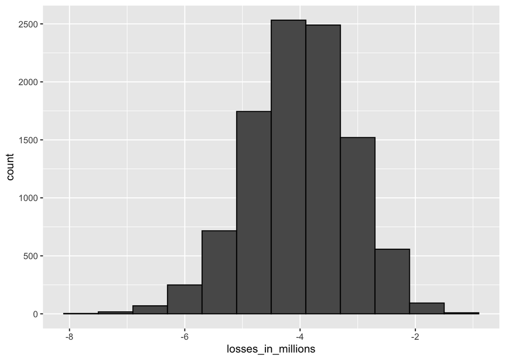

```r
data.frame(losses_in_millions = losses/10^6) %>%
  ggplot(aes(losses_in_millions)) +
  geom_histogram(binwidth = 0.6, col = "black")
```

*Code: Expected value and standard error of the sum of 1,000 loans*

```r
n*(p*loss_per_foreclosure + (1-p)*0)    # expected value
```

```
## [1] -4e+06
```

```r
sqrt(n)*abs(loss_per_foreclosure)*sqrt(p*(1-p))    # standard error
```

```
## [1] 885438
```

*Code: Calculating interest rates for expected value of 0*

We can calculate the amount $x$ to add to each loan so that the expected value is 0 using the equation $lp + x(1-p) = 0$. Note that this equation is the definition of expected value given a loss per foreclosure $l$ with foreclosure probability $p$ and profit $x$ if there is no foreclosure (probability $1-p$).

We solve for $x = - \frac {lp}{1-p}$ and calculate $x$:

```r
x = - loss_per_foreclosure*p/(1-p)
x
```

```
## [1] 4082
```

On a $180,000 loan, this equals an interest rate of:

```r
x/180000
```

```
## [1] 0.0227
```

*Equations: Calculating interest rate for 1% probability of losing money*

We want to calculate the value of $x$ for which $\mbox{Pr}(S < 0) = 0.01$. The expected value $E \left[ S \right]$ of the sum of $n = 1000$ loans given our definitions of $x$, $l$ and $p$ is:

$\mu_S = (lp + x(1-p))*n$

And the standard error of the sum of $n$ loans, $SE \left [ S \right]$, is:

$\sigma_S = |x-l|\sqrt{np(1-p)}$

Because we know the definition of a Z-score is $Z = \frac{x-\mu}{\sigma}$, we know that $\mbox{Pr}(S < 0) = \mbox{Pr}(Z < - \frac{\mu}{\sigma})$. Thus, $\mbox{Pr}(S < 0) = 0.01$ equals:

$\mbox{Pr}(Z < \frac{-[lp + x(1-p)]n}{(x-l)\sqrt{np(1-p)}}) = 0.01$

We know that `z<-qnorm(0.01)` gives us the value of $z$ for which $\mbox{Pr}(Z \le z) = 0.01$, meaning:

$z = \frac{-[lp + x(1-p)]n}{(x-l)\sqrt{np(1-p)}}$

Solving for $x$ gives:

$x = -l \frac {np - z \sqrt{np(1-p)}}{n(1-p) + z \sqrt{np(1-p)}}$

*Code: Calculating interest rate for 1% probability of losing money*

```r
l <- loss_per_foreclosure
z <- qnorm(0.01)
x <- -l*( n*p - z*sqrt(n*p*(1-p)))/ ( n*(1-p) + z*sqrt(n*p*(1-p)))
x    # required profit when loan is not a foreclosure
```

```
## [1] 6249
```

```r
x/180000    # interest rate
```

```
## [1] 0.0347
```

```r
loss_per_foreclosure*p + x*(1-p)    # expected value of the profit per loan
```

```
## [1] 2124
```

```r
n*(loss_per_foreclosure*p + x*(1-p)) # expected value of the profit over n loans
```

```
## [1] 2124198
```

*Code: Monte Carlo simulation for 1% probability of losing money*

Note that your results will vary from the video because the seed is not set.

```r
B <- 100000
profit <- replicate(B, {
    draws <- sample( c(x, loss_per_foreclosure), n,
                        prob=c(1-p, p), replace = TRUE)
    sum(draws)
})
mean(profit)    # expected value of the profit over n loans
```

```
## [1] 2126219
```

```r
mean(profit<0)    # probability of losing money
```

```
## [1] 0.0125
```

## The Big Short

The textbook for this section is available [here](https://rafalab.github.io/dsbook/random-variables.html#the-big-short).

**Key points**

- The Central Limit Theorem states that the sum of independent draws of a random variable follows a normal distribution. However, when the draws are not independent, this assumption does not hold.
- If an event changes the probability of default for all borrowers, then the probability of the bank losing money changes.
- Monte Carlo simulations can be used to model the effects of unknown changes in the probability of default.

*Code: Expected value with higher default rate and interest rate*

```r
p <- .04
loss_per_foreclosure <- -200000
r <- 0.05
x <- r*180000
loss_per_foreclosure*p + x*(1-p)
```

```
## [1] 640
```

*Equations: Probability of losing money*

We can define our desired probability of losing money, $z$, as:

$\mbox{Pr}(S < 0) = \mbox{Pr}(Z < - \frac{E \left [S \right]}{SE \left [S \right]}) = \mbox{Pr}(Z < z)$

If $\mu$ is the expected value of the urn (one loan) and $\sigma$ is the standard deviation of the urn (one loan), then $E \left [S \right] = n \mu$ and $SE \left [S \right] = \sqrt{n \sigma}$.

We define the probability of losing money $z = 0.01$. In the first equation, we can see that:

$z = - \frac{E \left [S \right]}{SE \left [S \right]}$

It follows that:

$z = - \frac {n \mu}{\sqrt{n \sigma}} = - \frac {\sqrt{n \mu}}{\sigma}$

To find the value of $n$ for which $z$ is less than or equal to our desired value, we take $z \le - \frac {\sqrt{n \mu}}{\sigma}$ and solve for $n$:

$n \ge \frac {z^2 \sigma^2}{\mu^2}$

*Code: Calculating number of loans for desired probability of losing money*

The number of loans required is:

```r
z <- qnorm(0.01)
l <- loss_per_foreclosure
n <- ceiling((z^2*(x-l)^2*p*(1-p))/(l*p + x*(1-p))^2)
n    # number of loans required
```

```
## [1] 22163
```

```r
n*(loss_per_foreclosure*p + x * (1-p))    # expected profit over n loans
```

```
## [1] 14184320
```

Code: Monte Carlo simulation with known default probability

This Monte Carlo simulation estimates the expected profit given a known probability of default $p = 0.04$. Note that your results will differ from the video because the seed is not set.

```r
B <- 10000
p <- 0.04
x <- 0.05 * 180000
profit <- replicate(B, {
    draws <- sample( c(x, loss_per_foreclosure), n,
                        prob=c(1-p, p), replace = TRUE)
    sum(draws)
})
mean(profit)
```

```
## [1] 14182962
```

*Code: Monte Carlo simulation with unknown default probability*

This Monte Carlo simulation estimates the expected profit given an unknown probability of default $0.03 \le p \le 0.05$, modeling the situation where an event changes the probability of default for all borrowers simultaneously. Note that your results will differ from the video because the seed is not set.

```r
p <- 0.04
x <- 0.05*180000
profit <- replicate(B, {
    new_p <- 0.04 + sample(seq(-0.01, 0.01, length = 100), 1)
    draws <- sample( c(x, loss_per_foreclosure), n,
                        prob=c(1-new_p, new_p), replace = TRUE)
    sum(draws)
})
mean(profit)    # expected profit
```

```
## [1] 14074302
```

```r
mean(profit < 0)    # probability of losing money
```

```
## [1] 0.348
```

```r
mean(profit < -10000000)    # probability of losing over $10 million
```

```
## [1] 0.241
```

## Assessment - The Big Short

1. Say you manage a bank that gives out 10,000 loans.

The default rate is 0.03 and you lose $200,000 in each foreclosure.

Create a random variable $S$ that contains the earnings of your bank. Calculate the total amount of money lost in this scenario.

```r
# Assign the number of loans to the variable `n`
n <- 10000

# Assign the loss per foreclosure to the variable `loss_per_foreclosure`
loss_per_foreclosure <- -200000

# Assign the probability of default to the variable `p_default`
p_default <- 0.03

# Use the `set.seed` function to make sure your answer matches the expected result after random sampling
set.seed(1)

# Generate a vector called `defaults` that contains the default outcomes of `n` loans
defaults <- sample( c(0,1), n, prob=c(1-p_default, p_default), replace = TRUE)

# Generate `S`, the total amount of money lost across all foreclosures. Print the value to the console.
S <- sum(defaults * loss_per_foreclosure)
S
```

```
## [1] -6.3e+07
```

2. Run a Monte Carlo simulation with 10,000 outcomes for $S$, the sum of losses over 10,000 loans. Make a histogram of the results.

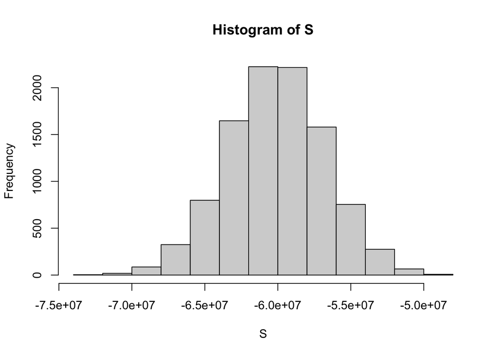

```r
# Assign the number of loans to the variable `n`
n <- 10000

# Assign the loss per foreclosure to the variable `loss_per_foreclosure`
loss_per_foreclosure <- -200000

# Assign the probability of default to the variable `p_default`
p_default <- 0.03

# Use the `set.seed` function to make sure your answer matches the expected result after random sampling
set.seed(1)

# The variable `B` specifies the number of times we want the simulation to run
B <- 10000

# Generate a list of summed losses 'S'. Replicate the code from the previous exercise over 'B' iterations to generate a list of summed losses for 'n' loans.  Ignore any warnings for now.
S <- replicate(B, {
    defaults <- sample( c(0,1), n, prob=c(1-p_default, p_default), replace = TRUE)
  sum(defaults * loss_per_foreclosure)
})

# Plot a histogram of 'S'.  Ignore any warnings for now.
hist(S)
```

3. What is the expected value of $S$, the sum of losses over 10,000 loans? For now, assume a bank makes no money if the loan is paid.

```r
# Assign the number of loans to the variable `n`
n <- 10000

# Assign the loss per foreclosure to the variable `loss_per_foreclosure`
loss_per_foreclosure <- -200000

# Assign the probability of default to the variable `p_default`
p_default <- 0.03

# Calculate the expected loss due to default out of 10,000 loans
n*(p_default*loss_per_foreclosure + (1-p_default)*0)
```

```
## [1] -6e+07
```

4. What is the standard error of $S$?

```r
# Assign the number of loans to the variable `n`
n <- 10000

# Assign the loss per foreclosure to the variable `loss_per_foreclosure`
loss_per_foreclosure <- -200000

# Assign the probability of default to the variable `p_default`
p_default <- 0.03

# Compute the standard error of the sum of 10,000 loans
sqrt(n)*abs(loss_per_foreclosure)*sqrt(p_default*(1-p_default))
```

```
## [1] 3411744
```

5. So far, we’ve been assuming that we make no money when people pay their loans and we lose a lot of money when people default on their loans.

Assume we give out loans for $180,000. How much money do we need to make when people pay their loans so that our net loss is $0?

In other words, what interest rate do we need to charge in order to not lose money?

```r
# Assign the loss per foreclosure to the variable `loss_per_foreclosure`
loss_per_foreclosure <- -200000

# Assign the probability of default to the variable `p_default`
p_default <- 0.03

# Assign a variable `x` as the total amount necessary to have an expected outcome of $0
x = - loss_per_foreclosure*p_default/(1-p_default)

# Convert `x` to a rate, given that the loan amount is $180,000. Print this value to the console.
x <- x/180000
x
```

```
## [1] 0.0344
```

6. With the interest rate calculated in the last example, we still lose money 50% of the time.

What should the interest rate be so that the chance of losing money is 1 in 20?

In math notation, what should the interest rate be so that $\mbox{Pr}(S < 0) = 0.05$?

Remember that we can add a constant to both sides of the equation to get:

$\mbox{Pr}(\frac{S−E \left [S \right ]}{SE \left [S \right ]} < \frac{−E \left [S \right ]}{SE \left [S \right ]})$

which is

$\mbox{Pr}(Z < \frac{-[lp + x(1-p)]n}{(x-l)\sqrt{np(1-p)}}) = 0.05$

Let `z = qnorm(0.05)` give us the value of `z` for which:

$\mbox{Pr}(Z \le z) = 0.05$

```r
# Assign the number of loans to the variable `n`
n <- 10000

# Assign the loss per foreclosure to the variable `loss_per_foreclosure`
loss_per_foreclosure <- -200000

# Assign the probability of default to the variable `p_default`
p_default <- 0.03

# Generate a variable `z` using the `qnorm` function
z <- qnorm(0.05)

# Generate a variable `x` using `z`, `p_default`, `loss_per_foreclosure`, and `n`
x <- -loss_per_foreclosure*( n*p_default - z*sqrt(n*p_default*(1-p_default)))/ ( n*(1-p_default) + z*sqrt(n*p_default*(1-p_default)))

# Convert `x` to an interest rate, given that the loan amount is $180,000. Print this value to the console.
x <- x/180000
x
```

```
## [1] 0.0377
```

7. The bank wants to minimize the probability of losing money.

Which of the following achieves their goal without making interest rates go up?

- A. A smaller pool of loans
- B. A larger probability of default
- C. A reduced default rate
- D. A larger cost per loan default

## Assessment - The Big Short (edX)

These exercises review and assess the following concepts:

- Expected value and standard error of a single draw of a random variable
- Expected value and standard error of the sum of draws of a random variable
- Monte Carlo simulation of the sum of draws of a random variable
- The Central Limit Theorem approximation of the sum of draws of a random variable
- Using z-scores to calculate values related to the normal distribution and normal random variables
- Calculating interest/premium rates to minimize chance of losing money
- Determining a number of loans/policies required to profit
- Simulating the effects of a change in event probability

**Setup and libraries**

Run the code below to set up your environment and load the libraries you will need for the following exercises:

```r
library(tidyverse)
library(dslabs)
```

```r
options(digits = 3)
```

*IMPORTANT*: Some of these exercises use **dslabs** datasets that were added in a July 2019 update. Make sure your package is up to date with the command `update.packages("dslabs")`. You can also update all packages on your system by running `update.packages()` with no arguments, and you should consider doing this routinely.

**Background**

In the motivating example **The Big Short**, we discussed how discrete and continuous probability concepts relate to bank loans and interest rates. Similar business problems are faced by the insurance industry.

Just as banks must decide how much to charge as interest on loans based on estimates of loan defaults, insurance companies must decide how much to charge as premiums for policies given estimates of the probability that an individual will collect on that policy.

We will use data from 2015 [US Period Life Tables](https://www.ssa.gov/oact/STATS/table4c6.html). Here is the code you will need to load and examine the data from **dslabs**:

```r
data(death_prob)
head(death_prob)
```

```
##   age  sex     prob
## 1   0 Male 0.006383
## 2   1 Male 0.000453
## 3   2 Male 0.000282
## 4   3 Male 0.000230
## 5   4 Male 0.000169
## 6   5 Male 0.000155
```

There are six multi-part questions for you to answer that follow.

#### 1. and 2. Insurance rates, part 1

Use the information below as you answer this 6-part question.

An insurance company offers a one-year term life insurance policy that pays $150,000 in the event of death within one year. The premium (annual cost) for this policy for a 50 year old female is $1,150. Suppose that in the event of a claim, the company forfeits the premium and loses a total of $150,000, and if there is no claim the company gains the premium amount of $1,150. The company plans to sell 1,000 policies to this demographic.

1a. The `death_prob` data frame contains information about the estimated probability of death within 1 year (`prob`) for different ages and sexes.

Use `death_prob` to determine the death probability of a 50 year old female, `p`.

```r
p <- death_prob %>%
  filter(sex == "Female" & age == "50") %>%
  pull(prob)
p
```

```
## [1] 0.00319
```

1b. The loss in the event of the policy holder’s death is -$150,000 and the gain if the policy holder remains alive is the premium $1,150.

What is the expected value of the company’s net profit on one policy for a 50 year old female?

```r
a <- -150000
b <- 1150

mu <- a*p + b*(1-p)
mu
```

```
## [1] 667
```

1c. Calculate the standard error of the profit on one policy for a 50 year old female.

```r
sigma <- abs(b-a) * sqrt(p*(1-p))
sigma
```

```
## [1] 8527
```

1d. What is the expected value of the company’s profit over all 1,000 policies for 50 year old females?

```r
n <- 1000
n*mu
```

```
## [1] 667378
```

1e. What is the standard error of the sum of the expected value over all 1,000 policies for 50 year old females?

```r
sqrt(n) * sigma
```

```
## [1] 269658
```

1f. Use the Central Limit Theorem to calculate the probability that the insurance company loses money on this set of 1,000 policies.

```r
pnorm(0, n*mu, sqrt(n)*sigma)
```

```
## [1] 0.00666
```

50 year old males have a different probability of death than 50 year old females. We will calculate a profitable premium for 50 year old males in the following four-part question.

2a. Use `death_prob` to determine the probability of death within one year for a 50 year old male.

```r
p_male <- death_prob %>%
  filter(sex == "Male" & age == "50") %>%
  pull(prob)
p_male
```

```
## [1] 0.00501
```

2b. Suppose the company wants its expected profits from 1,000 50 year old males with $150,000 life insurance policies to be $700,000.

Use the formula for expected value of the sum of draws with the following values and solve for the premium $b$:

$E \left [𝑆 \right ] = \mu S = 700000$

$n=1000$

$p = \mbox{death probability of age 50 male}$

$a = 150000$

$b = \mbox{premium}$

$\mu_S = n(ap + b(1-p))$

$b = \frac{\frac{\mu_S}{n}-ap}{1-p}$

What premium should be charged?

```r
p <- p_male
mu_sum <- 700000
n <- 1000
a <- -150000

b <- (mu_sum/n-a*p)/(1-p)
b
```

```
## [1] 1459
```

2c. Using the new 50 year old male premium rate, calculate the standard error of the sum of 1,000 premiums.

```r
sigma_sum <- sqrt(n)*abs(b-a)*sqrt(p*(1-p))
sigma_sum
```

```
## [1] 338262
```

2d. What is the probability of losing money on a series of 1,000 policies to 50 year old males?

Use the Central Limit Theorem.

```r
pnorm(0, mu_sum, sigma_sum)
```

```
## [1] 0.0193
```

#### 3. and 4. Insurance rates, part 2

Life insurance rates are calculated using mortality statistics from the recent past. They are priced such that companies are almost assured to profit as long as the probability of death remains similar. If an event occurs that changes the probability of death in a given age group, the company risks significant losses.

In this 6-part question, we’ll look at a scenario in which a lethal pandemic disease increases the probability of death within 1 year for a 50 year old to .015. Unable to predict the outbreak, the company has sold 1,000 $150,000 life insurance policies for $1,150.

3a. What is the expected value of the company’s profits over 1,000 policies?

```r
p <- .015    # probability of claim
a <- -150000    # loss per claim
b <- 1150    # premium - profit when no claim
n <- 1000

exp_val <- n*(a*p + b*(1-p))
exp_val
```

```
## [1] -1117250
```

3b. What is the standard error of the expected value of the company’s profits over 1,000 policies?

```r
se <- sqrt(n) * abs(b-a) * sqrt(p*(1-p))
se
```

```
## [1] 580994
```

3c. What is the probability of the company losing money?

```r
pnorm(0, exp_val, se)
```

```
## [1] 0.973
```

3d. Suppose the company can afford to sustain one-time losses of $1 million, but larger losses will force it to go out of business.

What is the probability of losing more than $1 million?

```r
pnorm(-1*10^6, exp_val, se)
```

```
## [1] 0.58
```

3e. Investigate death probabilities `p <- seq(.01, .03, .001)`.

What is the lowest death probability for which the chance of losing money exceeds 90%?

```r
p <- seq(.01, .03, .001)
a <- -150000    # loss per claim
b <- 1150    # premium - profit when no claim
n <- 1000

p_lose_money <- sapply(p, function(p){
  exp_val <- n*(a*p + b*(1-p))
  se <- sqrt(n) * abs(b-a) * sqrt(p*(1-p))
  pnorm(0, exp_val, se)
})

data.frame(p, p_lose_money) %>%
  filter(p_lose_money > 0.9) %>%
  pull(p) %>%
  min()
```

```
## [1] 0.013
```

3f. Investigate death probabilities `p <- seq(.01, .03, .0025)`.

What is the lowest death probability for which the chance of losing over $1 million exceeds 90%?

```r
p_lose_million <- sapply(p, function(p){
  exp_val <- n*(a*p + b*(1-p))
  se <- sqrt(n) * abs(b-a) * sqrt(p*(1-p))
  pnorm(-1*10^6, exp_val, se)
})

data.frame(p, p_lose_million) %>%
  filter(p_lose_million > 0.9) %>%
  pull(p) %>%
  min()
```

```
## [1] 0.02
```

4a. Define a sampling model for simulating the total profit over 1,000 loans with probability of claim `p_loss = .015`, loss of -$150,000 on a claim, and profit of $1,150 when there is no claim. Set the seed to 25, then run the model once.

(IMPORTANT! If you use R 3.6 or later, you will need to use the command `set.seed(x, sample.kind = "Rounding")` instead of `set.seed(x)`. Your R version will be printed at the top of the Console window when you start RStudio.)

What is the reported profit (or loss) in millions (that is, divided by $10^6$)?

```r
set.seed(25)

p <- .015
loss <- -150000
profit <- 1150
n <- 1000

outcomes <- sample(c(loss, profit), n, prob = c(p, 1-p), replace = TRUE)
sum(outcomes)/10^6
```

```
## [1] -1.42
```

4b. Set the seed to 27, then run a Monte Carlo simulation of your sampling model with 10,000 replicates to simulate the range of profits/losses over 1,000 loans.

(IMPORTANT! If you use R 3.6 or later, you will need to use the command `set.seed(x, sample.kind = "Rounding")` instead of `set.seed(x)`. Your R version will be printed at the top of the Console window when you start RStudio.)

What is the observed probability of losing $1 million or more?

```r
set.seed(27)
B <- 10000

profits <- replicate(B, {
  outcomes <- sample(c(loss, profit), n, prob = c(p, 1-p), replace = TRUE)
  sum(outcomes)/10^6
})

mean(profits < -1)
```

```
## [1] 0.539
```

#### 5. and 6. Insurance rates, part 3

Question 5, which has 4 parts, continues the pandemic scenario from Questions 3 and 4.

Suppose that there is a massive demand for life insurance due to the pandemic, and the company wants to find a premium cost for which the probability of losing money is under 5%, assuming the death rate stays stable at $p = 0.015$.

5a. Calculate the premium required for a 5% chance of losing money given $n = 1000$ loans, probability of death $p = 0.015$, and loss per claim $l = -150000$. Save this premium as `x` for use in further questions.

```r
p <- .015
n <- 1000
l <- -150000
z <- qnorm(.05)
x <- -l*( n*p - z*sqrt(n*p*(1-p)))/ ( n*(1-p) + z*sqrt(n*p*(1-p)))
x
```

```
## [1] 3268
```

5b. What is the expected profit per policy at this rate?

```r
l*p + x*(1-p)
```

```
## [1] 969
```

5c. What is the expected profit over 1,000 policies?

```r
mu <- n*(l*p + x*(1-p))
mu
```

```
## [1] 969042
```

5d. Run a Monte Carlo simulation with $B = 10000$ to determine the probability of losing money on 1,000 policies given the new premium `x`, loss on a claim of $150,000, and probability of claim $p = .015$. Set the seed to 28 before running your simulation.

(IMPORTANT! If you use R 3.6 or later, you will need to use the command `set.seed(x, sample.kind = "Rounding")` instead of `set.seed(x)`. Your R version will be printed at the top of the Console window when you start RStudio.)

What is the probability of losing money here?

```r
set.seed(28)
B <- 10000
profit <- replicate(B, {
  draws <- sample(c(x, l), n,
                  prob=c(1-p, p), replace = TRUE)
  sum(draws)
})

mean(profit < 0)
```

```
## [1] 0.0554
```

The company cannot predict whether the pandemic death rate will stay stable. Set the seed to 29, then write a Monte Carlo simulation that for each of $B = 10000$ iterations:

- randomly changes $p$ by adding a value between -0.01 and 0.01 with **sample(seq(-0.01, 0.01, length = 100), 1)**
- uses the new random $p$ to generate a sample of $n = 1000$ policies with premium **x** and loss per claim $l = -150000$
- returns the profit over $n$ policies (sum of random variable)

(IMPORTANT! If you use R 3.6 or later, you will need to use the command **set.seed(x, sample.kind = “Rounding”)** instead of **set.seed(x)**. Your R version will be printed at the top of the Console window when you start RStudio.)

(Hint: Use the process from lecture for modeling a situation for loans that changes the probability of default for all borrowers simultaneously.)

```r
# n, p, l and x as defined in the problem information
set.seed(29)    # in R 3.6, set.seed(29, sample.kind="Rounding")

profit <- replicate(B, {
    new_p <- p + sample(seq(-0.01, 0.01, length = 100), 1)
    draws <- sample(c(x, l), n,
                    prob=c(1-new_p, new_p), replace = TRUE)
    sum(draws)
})
```

6b. What is the probability of losing money?

```r
mean(profit < 0)
```

```
## [1] 0.191
```

6c. What is the probability of losing more than $1 million?

```r
mean(profit < -1*10^6)
```

```
## [1] 0.0424
```